# R Notebook

Problem1— Using ANN for Covid Sentiment classification 1)First use “qdap” package to remove stop words and do stemming

```r
cnt123=read.csv("C:/Users/prabh/Downloads/Corona_NLP_train.csv")
str(cnt123)
```

```
'data.frame':   41157 obs. of  6 variables:
 $ UserName     : int  3799 3800 3801 3802 3803 3804 3805 3806 3807 3808 ...
 $ ScreenName   : int  48751 48752 48753 48754 48755 48756 48757 48758 48759 48760 ...
 $ Location     : chr  "London" "UK" "Vagabonds" "" ...
 $ TweetAt      : chr  "16-03-2020" "16-03-2020" "16-03-2020" "16-03-2020" ...
 $ OriginalTweet: chr  "@MeNyrbie @Phil_Gahan @Chrisitv https://t.co/iFz9FAn2Pa and https://t.co/xX6ghGFzCC and https://t.co/I2NlzdxNo8" "advice Talk to your neighbours family to exchange phone numbers create contact list with phone numbers of neigh"| __truncated__ "Coronavirus Australia: Woolworths…
 $ Sentiment    : chr  "Neutral" "Positive" "Positive" "Positive" ...
```

```r
str(cnt123$Sentiment)
```

```
 chr [1:41157] "Neutral" "Positive" "Positive" "Positive" "Extremely Negative" ...
```

```r
library(qdap)
cnt123$OriginalTweet=rm_stopwords(cnt123$OriginalTweet, stopwords=tm::stopwords("english"), separate=FALSE, strip=TRUE)
cnt123$OriginalTweet=stemmer(cnt123$OriginalTweet, warn=FALSE)
```

2)Randomize the order of rows

```r
set.seed(123)
cnt123 = cnt123[sample(nrow(cnt123), replace=FALSE), ]
cnt123
```

|  | UserName | ScreenName | Location | TweetAt | OriginalTweet | Sentiment |
| --- | --- | --- | --- | --- | --- | --- |
| 2986 | 6784 | 51736 | Internet | 18-03-2020 | Coronavirus spread across america mani worker direct work home staff amazon wholefood squeez keep increas demand caus american stockpil food household product httpstcoowzjdp vzi | Negative |
| 29925 | 33723 | 78675 | London, Bloomsbury | 06-04-2020 | Prioriti appeal anyon self isol high risk vulner elder health condit categori pleas depriv book onlin supermarket shop slot | Extremely Positive |
| 29710 | 33508 | 78460 | new delhi,india | 05-04-2020 | Shallukapoor guptapradeepkr dnthakurji can control covid effect adot ayurvedsoci distancingcleanli eat vegetarian foodavoid panic stay home stay safe request pm | Negative |
| 37529 | 41327 | 86279 | Madeira Beach, FL | 10-04-2020 | Just yesterday orlando warehous distribut million mask face shield shoe cover gown glove contain hand sanit florida second highest state test | Positive |
| 2757 | 6555 | 51507 | Maldives | 18-03-2020 | Enough everyon work togeth uk supermarket besieg custom | Neutral |
| 38938 | 42736 | 87688 | California | 12-04-2020 | Gas price look love just might fill tank take min drive go back home coronavirus blacktwitt | Positive |
| 9642 | 13440 | 58392 | New Zealand | 20-03-2020 | Sound accur zombi apocalyps panic toiletpap covid covid supermarket fearmong funni nz httpstcodpn vqhbo | Neutral |
| 31313 | 35111 | 80063 | Downtown, Toronto | 06-04-2020 | Toronto real estat market amid covid price whyapril coronavirus effect torontoâ’ real estat market huge weâ’ll see perfect imag month come read bioor httpstco zlcq fqli toronto coronavirus httpstcodki… | Extremely Positive |
| 14183 | 17981 | 62933 | Jammu, Jammu and Kashmir(UT) | 21-03-2020 | Need panic govt fix price mask sanit hope avail think face nearest pharmaci coronavirusoutbreakindia coronachainscar corona covid coronavirusupd coronapandem httpstcoc blldyikr | Negative |
| 15180 | 18978 | 63930 | Singapore and the World | 22-03-2020 | Mother day mayhem till tesco supermarket forc shut dozen httpstcosuuimevczq via mailonlin | Negative |

[output cut: 990 more lines]

3)Convert sentiment into a factor variable with three levels: “positive, “neutral”, and “negative”. Then convert this factor variable to a numeric vector.

```r
cnt123$Sentiment=factor(cnt123$Sentiment)
levels(cnt123$Sentiment)
```

```
[1] "Extremely Negative" "Extremely Positive" "Negative"           "Neutral"
[5] "Positive"
```

```r
levels(cnt123$Sentiment)<-list(Positive = "Extremely Positive", Negative = "Extremely Negative", neutral = "Neutral")
levels(cnt123$Sentiment)
```

```
[1] "Positive" "Negative" "neutral"
```

```r
summary(as.factor(cnt123$Sentiment))
```

```
Positive Negative  neutral
   18046    15398     7713
```

```r
cnt123$Sentiment =as.numeric(cnt123[,"Sentiment"])-1
```

```r
str(cnt123$Sentiment)
```

```
 num [1:41157] 1 0 1 0 2 0 2 0 1 1 ...
```

4)Spit the data three ways in to train/validation/ and test sets as follows: use the first 26340 rows for training, next 6585 rows for validation, and the last 8232 rows for testing.

```r
cnt123_train<-cnt123[1:26340,-6]
cnt123_validation<-cnt123[26341:32925,-6 ]
cnt123_test<-cnt123[32926:41157, -6]


cnt123_train_labels<-cnt123[1:26340,6]
cnt123_validation_labels<-cnt123[26341:32925,6]
cnt123_test_labels<-cnt123[32926:41157,6]
```

5)Keras has a preprocessing layer, called layer_text_vectorization, this layer creates a document-term matrix where rows represent tweets and columns represent terms. Use the following code segment to create document-term matrix for your training, validation and test datasets you created above.

```r
library(keras)
text_vectorizer <- layer_text_vectorization(output_mode="tf_idf", ngrams =2, max_tokens = 5000)
text_vectorizer %>% adapt(cnt123_train$OriginalTweet)
cnt123_train_dtm = text_vectorizer(cnt123_train$OriginalTweet)
cnt123_validation_dtm =text_vectorizer(cnt123_validation$OriginalTweet)
cnt123_test_dtm = text_vectorizer(cnt123_test$OriginalTweet)
```

Training, Tuning, and Evaluating a Neural Network Model Q1.

```r
model <-keras_model_sequential() %>%
layer_dense(units = 64, activation = "relu", input_shape= dim(cnt123_train_dtm)[2]) %>%
layer_dense(units = 64,activation="relu" ) %>%
layer_dense(units = 3, activation="softmax")

model
```

```
Model: "sequential_1"
__________________________________________________________________________________________
 Layer (type)                           Output Shape                        Param #
==========================================================================================
 dense_5 (Dense)                        (None, 64)                          320064

 dense_4 (Dense)                        (None, 64)                          4160

 dense_3 (Dense)                        (None, 3)                           195

==========================================================================================
Total params: 324,419
Trainable params: 324,419
Non-trainable params: 0
__________________________________________________________________________________________
```

```r
model %>% compile(loss = "sparse_categorical_crossentropy", optimizer = "adam", metric = c("accuracy"))
model %>% fit(cnt123_train_dtm, cnt123_train_labels, epoch= 20,
batch_size=50, validation_data=list(cnt123_validation_dtm, cnt123_validation_labels))
```

```r
predicted_labels=as.numeric(model %>% predict(cnt123_test_dtm) %>%k_argmax())
```

```r
actual_labels= cnt123_test_labels
t=table(predicted_labels, actual_labels)
t
```

```
                actual_labels
predicted_labels    0    1    2
               0 2637  496  255
               1  554 2362  347
               2  327  323  931
```

ans: 2637-Positive observations, 2362-Negative observations, 931-neutral observations has been predicted correctly. Mostly the data is predicted correctly. 751 observations are predicted wrongly as “Positive” whereas 901 observations are wrongly predicted as “negative”.

```r
library(tfruns)
runs=tuning_run("cnt123_hyperparameters.R",
            flags = list(
              learning_rate = c(0.1, 0.01, 0.001, 0.0001),
              batch_size = c(64,64,3),
              activation_function = c("relu","softmax","tanh"),
              units1= c(16,32,64,128),
              units2= c(16,32,64,128)
            ),
            sample = 0.01
 )
```

```
576 total combinations of flags
(sampled to 6 combinations)

Training run 1/6 (flags = list(0.01, 3, "tanh", 64, 32))
```

```r
runs=runs[order(runs$metric_val_accuracy, decreasing=TRUE),]
runs
```

```
Data frame: 6 x 25
```

|  | run_dir | metric_loss | metric_accuracy | metric_val_loss | metric_val_accuracy |
| --- | --- | --- | --- | --- | --- |
| 1 | runs/2022-04-07T02-39-31Z | 0.1736 | 0.9591 | 0.9432 | 0.7443 |
| 2 | runs/2022-04-07T02-27-04Z | 0.0581 | 0.9843 | 1.3615 | 0.7314 |
| 4 | runs/2022-04-07T02-20-03Z | 0.0226 | 0.9930 | 2.3409 | 0.7285 |
| 5 | runs/2022-04-07T02-16-22Z | 0.0324 | 0.9946 | 1.3960 | 0.7175 |
| 6 | runs/2022-04-07T01-52-07Z | 0.6438 | 0.7483 | 0.7935 | 0.6934 |
| 3 | runs/2022-04-07T02-23-51Z | 0.7632 | 0.7423 | 0.8124 | 0.6866 |

```
# ... with 20 more columns:
#   flag_learning_rate, flag_units1, flag_units2, flag_batch_size,
#   flag_activation_function, epochs, epochs_completed, metrics, model,
#   loss_function, optimizer, learning_rate, script, start, end, completed, output,
#   source_code, context, type
```

```r
library(tfruns)
view_run(runs$run_dir[1])
```

ans: We see that the validation_loss is always greater than the training loss, this means that network is overfitting the training data. We see that after about 7 epochs the validation loss does not decrease anymore while the training loss still continue to decrease.

```r
cnt123_train_new=as.matrix(cnt123_train_dtm)
cnt123_validation_new=as.matrix(cnt123_validation_dtm)
cnt123_newdata=rbind(cnt123_train_new, cnt123_validation_new)
cnt123_newdata_labels=c(cnt123_train_labels, cnt123_validation_labels)
```

```r
library(keras)
model <-keras_model_sequential() %>%
layer_dense(units = 16, activation = "softmax", input_shape= dim(cnt123_newdata)[2]) %>%
layer_dense(units = 16,activation="softmax" ) %>%
layer_dense(units = 3, activation="softmax")

model %>% compile(loss = "sparse_categorical_crossentropy", optimizer = optimizer_adam(learning_rate=0.001), metric = c("accuracy"))
model %>% fit(cnt123_newdata, cnt123_newdata_labels, epoch= 20,
batch_size=64, validation_data=list(as.matrix(cnt123_validation_dtm), cnt123_validation_labels))
```

3)Evaluating the best model on the test data

```r
model %>% evaluate(as.matrix(cnt123_test_dtm), cnt123_test_labels)
```

```
     loss  accuracy
0.8327411 0.7616618
```

ans: The accuracy of naïve Bayes model in assignment 2= 0.63824101 The accuracy of ANN model in assignment 4= 0.7616618 this model performs better when compared to naïve Bayes model in assignment 2.

Problem2—Predicting Baseball players’ salaries

1)Download the dataset hitters.csv and explore the overall structure of the dataset using the str() function. Get a summary statistics of each variable. Answer the following questions: o How many observations do you have in the data? o How many categorical and numeric variables you have in your data? o Is there any missing value?

```r
hittersdata = read.csv("C:/Users/prabh/Downloads/hitters.csv", stringsAsFactors = TRUE)
str(hittersdata)
```

```
'data.frame':   322 obs. of  20 variables:
 $ AtBat    : int  293 315 479 496 321 594 185 298 323 401 ...
 $ Hits     : int  66 81 130 141 87 169 37 73 81 92 ...
 $ HmRun    : int  1 7 18 20 10 4 1 0 6 17 ...
 $ Runs     : int  30 24 66 65 39 74 23 24 26 49 ...
 $ RBI      : int  29 38 72 78 42 51 8 24 32 66 ...
 $ Walks    : int  14 39 76 37 30 35 21 7 8 65 ...
 $ Years    : int  1 14 3 11 2 11 2 3 2 13 ...
 $ CAtBat   : int  293 3449 1624 5628 396 4408 214 509 341 5206 ...
 $ CHits    : int  66 835 457 1575 101 1133 42 108 86 1332 ...
 $ CHmRun   : int  1 69 63 225 12 19 1 0 6 253 ...
 $ CRuns    : int  30 321 224 828 48 501 30 41 32 784 ...
 $ CRBI     : int  29 414 266 838 46 336 9 37 34 890 ...
 $ CWalks   : int  14 375 263 354 33 194 24 12 8 866 ...
 $ League   : Factor w/ 2 levels "A","N": 1 2 1 2 2 1 2 1 2 1 ...
 $ Division : Factor w/ 2 levels "E","W": 1 2 2 1 1 2 1 2 2 1 ...
 $ PutOuts  : int  446 632 880 200 805 282 76 121 143 0 ...
 $ Assists  : int  33 43 82 11 40 421 127 283 290 0 ...
 $ Errors   : int  20 10 14 3 4 25 7 9 19 0 ...
 $ Salary   : num  NA 475 480 500 91.5 750 70 100 75 1100 ...
 $ NewLeague: Factor w/ 2 levels "A","N": 1 2 1 2 2 1 1 1 2 1 ...
```

```r
summary(hittersdata)
```

```
     AtBat            Hits         HmRun            Runs             RBI
 Min.   : 16.0   Min.   :  1   Min.   : 0.00   Min.   :  0.00   Min.   :  0.00
 1st Qu.:255.2   1st Qu.: 64   1st Qu.: 4.00   1st Qu.: 30.25   1st Qu.: 28.00
 Median :379.5   Median : 96   Median : 8.00   Median : 48.00   Median : 44.00
 Mean   :380.9   Mean   :101   Mean   :10.77   Mean   : 50.91   Mean   : 48.03
 3rd Qu.:512.0   3rd Qu.:137   3rd Qu.:16.00   3rd Qu.: 69.00   3rd Qu.: 64.75
 Max.   :687.0   Max.   :238   Max.   :40.00   Max.   :130.00   Max.   :121.00

     Walks            Years            CAtBat            CHits            CHmRun
 Min.   :  0.00   Min.   : 1.000   Min.   :   19.0   Min.   :   4.0   Min.   :  0.00
 1st Qu.: 22.00   1st Qu.: 4.000   1st Qu.:  816.8   1st Qu.: 209.0   1st Qu.: 14.00
 Median : 35.00   Median : 6.000   Median : 1928.0   Median : 508.0   Median : 37.50
 Mean   : 38.74   Mean   : 7.444   Mean   : 2648.7   Mean   : 717.6   Mean   : 69.49
 3rd Qu.: 53.00   3rd Qu.:11.000   3rd Qu.: 3924.2   3rd Qu.:1059.2   3rd Qu.: 90.00
 Max.   :105.00   Max.   :24.000   Max.   :14053.0   Max.   :4256.0   Max.   :548.00

     CRuns             CRBI             CWalks        League  Division    PutOuts
 Min.   :   1.0   Min.   :   0.00   Min.   :   0.00   A:175   E:157    Min.   :   0.0
 1st Qu.: 100.2   1st Qu.:  88.75   1st Qu.:  67.25   N:147   W:165    1st Qu.: 109.2
 Median : 247.0   Median : 220.50   Median : 170.50                    Median : 212.0
 Mean   : 358.8   Mean   : 330.12   Mean   : 260.24                    Mean   : 288.9
 3rd Qu.: 526.2   3rd Qu.: 426.25   3rd Qu.: 339.25                    3rd Qu.: 325.0
 Max.   :2165.0   Max.   :1659.00   Max.   :1566.00                    Max.   :1378.0

    Assists          Errors          Salary       NewLeague
 Min.   :  0.0   Min.   : 0.00   Min.   :  67.5   A:176
 1st Qu.:  7.0   1st Qu.: 3.00   1st Qu.: 190.0   N:146
 Median : 39.5   Median : 6.00   Median : 425.0
 Mean   :106.9   Mean   : 8.04   Mean   : 535.9
 3rd Qu.:166.0   3rd Qu.:11.00   3rd Qu.: 750.0
 Max.   :492.0   Max.   :32.00   Max.   :2460.0
                                 NA's   :59
```

```r
sapply(colnames(hittersdata), function(x) class(hittersdata[[x]]))
```

```
    AtBat      Hits     HmRun      Runs       RBI     Walks     Years    CAtBat     CHits
"integer" "integer" "integer" "integer" "integer" "integer" "integer" "integer" "integer"
   CHmRun     CRuns      CRBI    CWalks    League  Division   PutOuts   Assists    Errors
"integer" "integer" "integer" "integer"  "factor"  "factor" "integer" "integer" "integer"
   Salary NewLeague
"numeric"  "factor"
```

```r
which(is.na(hittersdata))
```

```
 [1] 5797 5812 5815 5819 5827 5829 5833 5835 5836 5838 5839 5841 5845 5849 5854 5861 5863
[18] 5866 5868 5874 5877 5880 5891 5894 5898 5900 5901 5902 5903 5911 5922 5935 5941 5947
[35] 5954 5955 5957 5966 5968 5970 5994 5996 6000 6005 6007 6022 6025 6032 6043 6047 6050
[52] 6051 6067 6080 6089 6095 6099 6102 6113
```

```r
colSums(is.na(hittersdata))
```

```
    AtBat      Hits     HmRun      Runs       RBI     Walks     Years    CAtBat     CHits
        0         0         0         0         0         0         0         0         0
   CHmRun     CRuns      CRBI    CWalks    League  Division   PutOuts   Assists    Errors
        0         0         0         0         0         0         0         0         0
   Salary NewLeague
       59         0
```

ans: we have 322 observations of 20 variables in the data. we have 3 categorical variables and 17 numeric variables in the data. Yes, there are 59 NA values in the Salary variable.

o Draw the histogram of salary. Interpret what you see in the histogram.

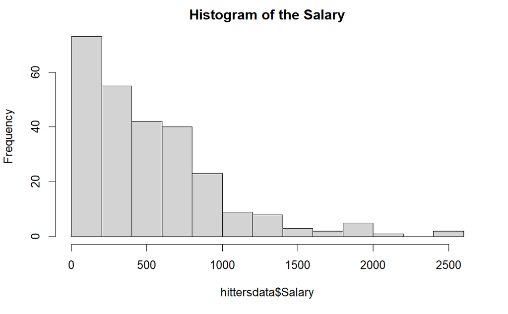

```r
hist(hittersdata$Salary, main = "Histogram of the Salary")
```

ans: Histogram of salary variable is Right_skewed, the tallest bar is at the left hand side of the diagram. Maximum members in the data are receiving salaries between 0-1000.

2)remove the observation for which Salary value is missing

```r
hittersdata=na.omit(hittersdata)
str(hittersdata)
```

```
'data.frame':   263 obs. of  20 variables:
 $ AtBat    : int  315 479 496 321 594 185 298 323 401 574 ...
 $ Hits     : int  81 130 141 87 169 37 73 81 92 159 ...
 $ HmRun    : int  7 18 20 10 4 1 0 6 17 21 ...
 $ Runs     : int  24 66 65 39 74 23 24 26 49 107 ...
 $ RBI      : int  38 72 78 42 51 8 24 32 66 75 ...
 $ Walks    : int  39 76 37 30 35 21 7 8 65 59 ...
 $ Years    : int  14 3 11 2 11 2 3 2 13 10 ...
 $ CAtBat   : int  3449 1624 5628 396 4408 214 509 341 5206 4631 ...
 $ CHits    : int  835 457 1575 101 1133 42 108 86 1332 1300 ...
 $ CHmRun   : int  69 63 225 12 19 1 0 6 253 90 ...
 $ CRuns    : int  321 224 828 48 501 30 41 32 784 702 ...
 $ CRBI     : int  414 266 838 46 336 9 37 34 890 504 ...
 $ CWalks   : int  375 263 354 33 194 24 12 8 866 488 ...
 $ League   : Factor w/ 2 levels "A","N": 2 1 2 2 1 2 1 2 1 1 ...
 $ Division : Factor w/ 2 levels "E","W": 2 2 1 1 2 1 2 2 1 1 ...
 $ PutOuts  : int  632 880 200 805 282 76 121 143 0 238 ...
 $ Assists  : int  43 82 11 40 421 127 283 290 0 445 ...
 $ Errors   : int  10 14 3 4 25 7 9 19 0 22 ...
 $ Salary   : num  475 480 500 91.5 750 ...
 $ NewLeague: Factor w/ 2 levels "A","N": 2 1 2 2 1 1 1 2 1 1 ...
 - attr(*, "na.action")= 'omit' Named int [1:59] 1 16 19 23 31 33 37 39 40 42 ...
  ..- attr(*, "names")= chr [1:59] "1" "16" "19" "23" ...
```

3)Which predictors have most correlation with Salary? Use scattered plot, side-by-side box plots, t-test and correlation matrix to answer this question.

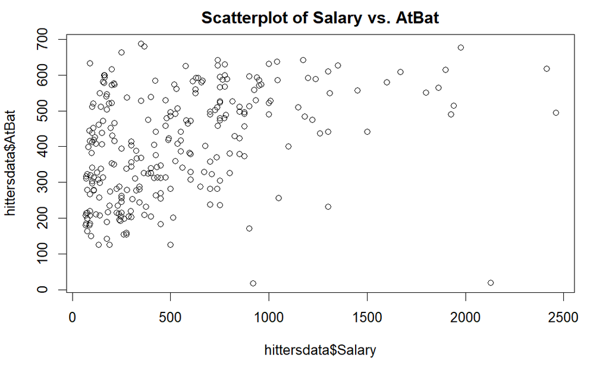

```r
attach(hittersdata)
plot(x = hittersdata$Salary , y = hittersdata$AtBat, main = "Scatterplot of Salary vs. AtBat")
```

```r
cor.test(Salary, AtBat)
```

```
    Pearson's product-moment correlation

data:  Salary and AtBat
t = 6.9415, df = 261, p-value = 3.065e-11
alternative hypothesis: true correlation is not equal to 0
95 percent confidence interval:
 0.2875446 0.4922239
sample estimates:
      cor
0.3947709
```

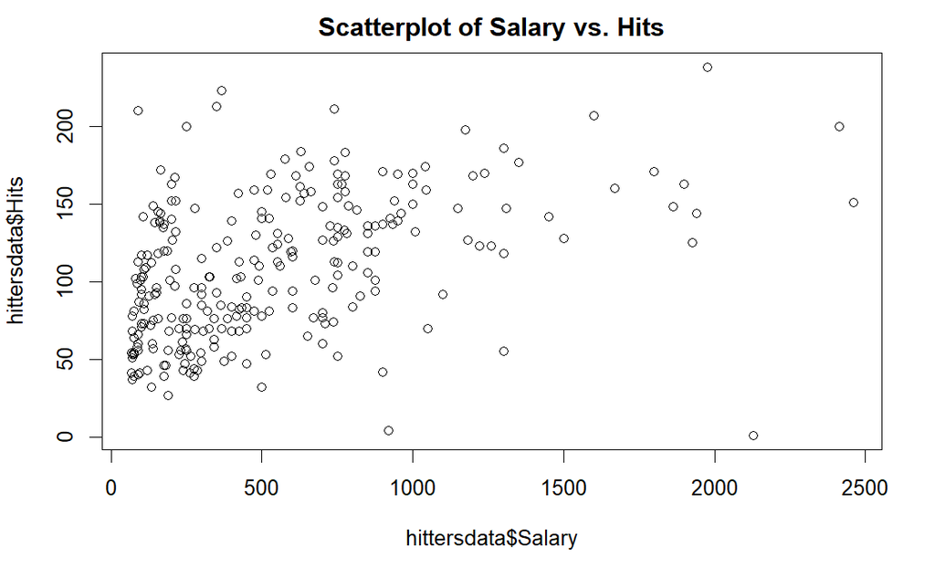

```r
plot(x = hittersdata$Salary , y = hittersdata$Hits, main = "Scatterplot of Salary vs. Hits")
```

```r
cor.test(Salary, Hits)
```

```
    Pearson's product-moment correlation

data:  Salary and Hits
t = 7.8863, df = 261, p-value = 8.531e-14
alternative hypothesis: true correlation is not equal to 0
95 percent confidence interval:
 0.3355210 0.5314332
sample estimates:
      cor
0.4386747
```

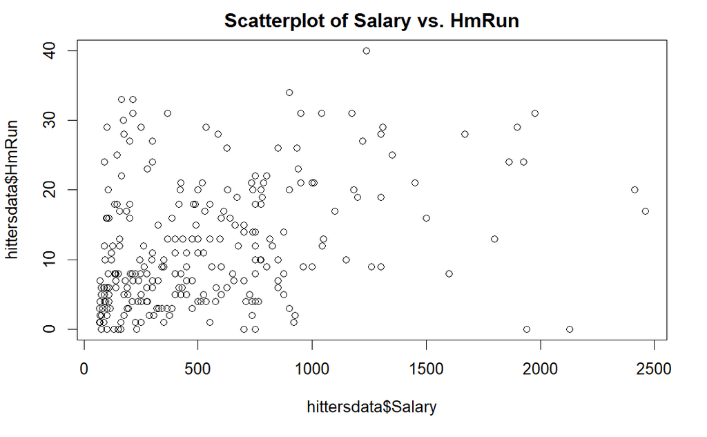

```r
plot(x = hittersdata$Salary , y = hittersdata$HmRun, main = "Scatterplot of Salary vs. HmRun")
```

```r
cor.test(Salary, HmRun)
```

```
    Pearson's product-moment correlation

data:  Salary and HmRun
t = 5.8998, df = 261, p-value = 1.125e-08
alternative hypothesis: true correlation is not equal to 0
95 percent confidence interval:
 0.2316843 0.4455003
sample estimates:
      cor
0.3430281
```

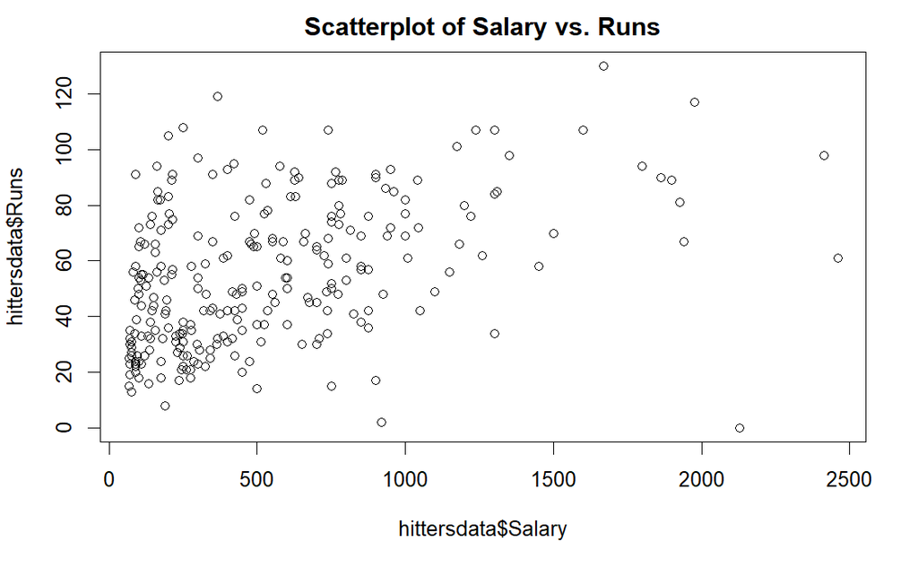

```r
plot(x = hittersdata$Salary , y = hittersdata$Runs, main = "Scatterplot of Salary vs. Runs")
```

```r
cor.test(Salary, Runs)
```

```
    Pearson's product-moment correlation

data:  Salary and Runs
t = 7.4737, df = 261, p-value = 1.18e-12
alternative hypothesis: true correlation is not equal to 0
95 percent confidence interval:
 0.3148937 0.5146775
sample estimates:
      cor
0.4198586
```

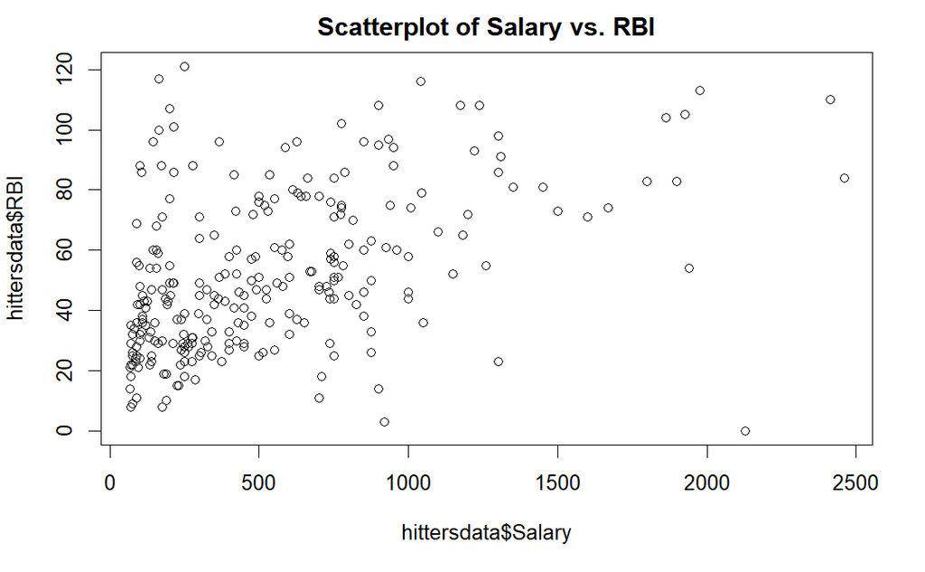

```r
plot(x = hittersdata$Salary , y = hittersdata$RBI, main = "Scatterplot of Salary vs. RBI")
```

```r
cor.test(Salary, RBI)
```

```
    Pearson's product-moment correlation

data:  Salary and RBI
t = 8.1285, df = 261, p-value = 1.757e-14
alternative hypothesis: true correlation is not equal to 0
95 percent confidence interval:
 0.3473860 0.5410023
sample estimates:
      cor
0.4494571
```

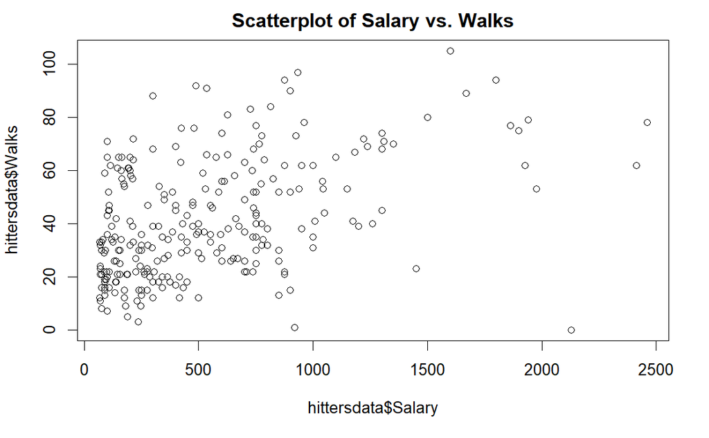

```r
plot(x = hittersdata$Salary , y = hittersdata$Walks, main = "Scatterplot of Salary vs. Walks")
```

```r
cor.test(Salary, Walks)
```

```
    Pearson's product-moment correlation

data:  Salary and Walks
t = 8.0024, df = 261, p-value = 4.014e-14
alternative hypothesis: true correlation is not equal to 0
95 percent confidence interval:
 0.3412308 0.5360444
sample estimates:
      cor
0.4438673
```

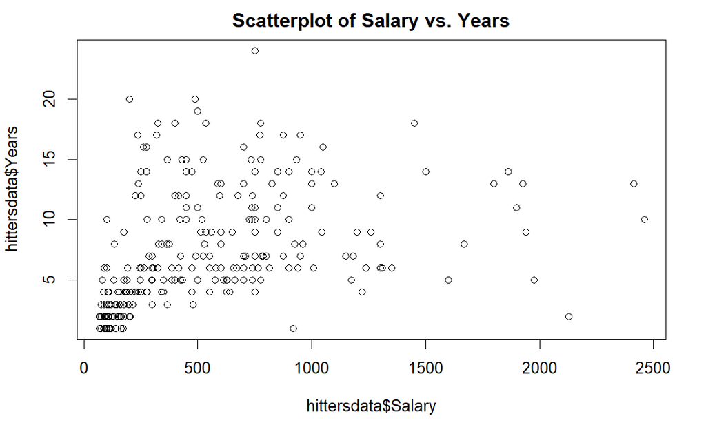

```r
plot(x = hittersdata$Salary , y = hittersdata$Years, main = "Scatterplot of Salary vs. Years")
```

```r
cor.test(Salary, Years)
```

```
    Pearson's product-moment correlation

data:  Salary and Years
t = 7.0646, df = 261, p-value = 1.463e-11
alternative hypothesis: true correlation is not equal to 0
95 percent confidence interval:
 0.2939455 0.4975036
sample estimates:
     cor
0.400657
```

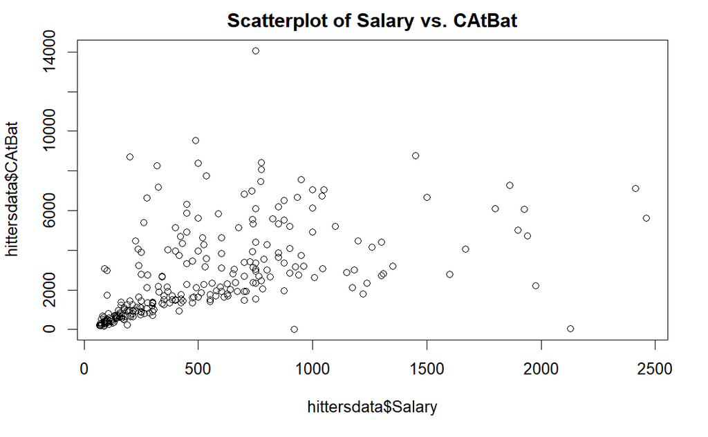

```r
plot(x = hittersdata$Salary , y = hittersdata$CAtBat, main = "Scatterplot of Salary vs. CAtBat")
```

```r
cor.test(Salary, CAtBat)
```

```
    Pearson's product-moment correlation

data:  Salary and CAtBat
t = 9.9953, df = 261, p-value < 2.2e-16
alternative hypothesis: true correlation is not equal to 0
95 percent confidence interval:
 0.4327165 0.6083752
sample estimates:
      cor
0.5261353
```

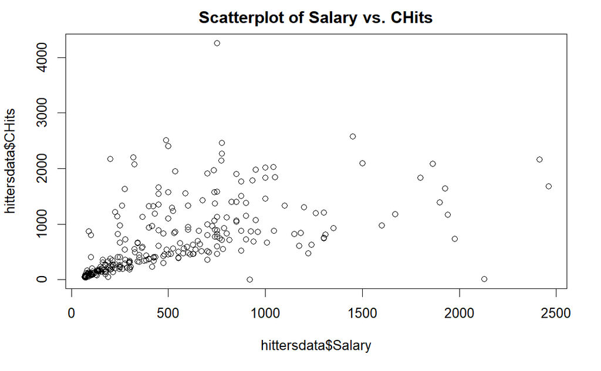

```r
plot(x = hittersdata$Salary , y = hittersdata$CHits, main = "Scatterplot of Salary vs. CHits")
```

```r
cor.test(Salary, CHits)
```

```
    Pearson's product-moment correlation

data:  Salary and CHits
t = 10.609, df = 261, p-value < 2.2e-16
alternative hypothesis: true correlation is not equal to 0
95 percent confidence interval:
 0.4583872 0.6281600
sample estimates:
      cor
0.5489096
```

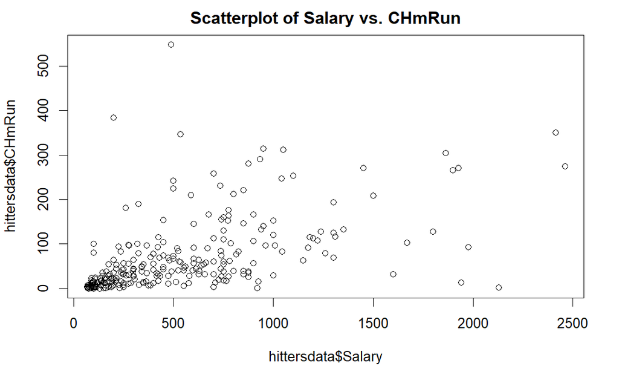

```r
plot(x = hittersdata$Salary , y = hittersdata$CHmRun, main = "Scatterplot of Salary vs. CHmRun")
```

```r
cor.test(Salary, CHmRun)
```

```
    Pearson's product-moment correlation

data:  Salary and CHmRun
t = 9.9637, df = 261, p-value < 2.2e-16
alternative hypothesis: true correlation is not equal to 0
95 percent confidence interval:
 0.4313628 0.6073258
sample estimates:
      cor
0.5249306
```

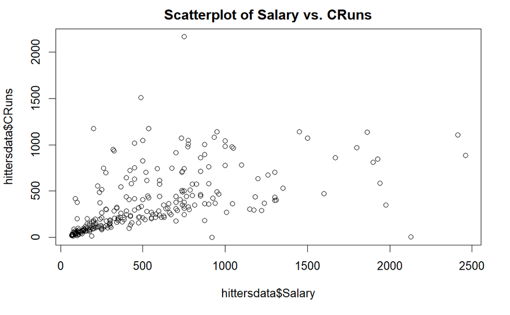

```r
plot(x = hittersdata$Salary , y = hittersdata$CRuns, main = "Scatterplot of Salary vs. CRuns")
```

```r
cor.test(Salary, CRuns)
```

```
    Pearson's product-moment correlation

data:  Salary and CRuns
t = 10.996, df = 261, p-value < 2.2e-16
alternative hypothesis: true correlation is not equal to 0
95 percent confidence interval:
 0.4739799 0.6400714
sample estimates:
      cor
0.5626777
```

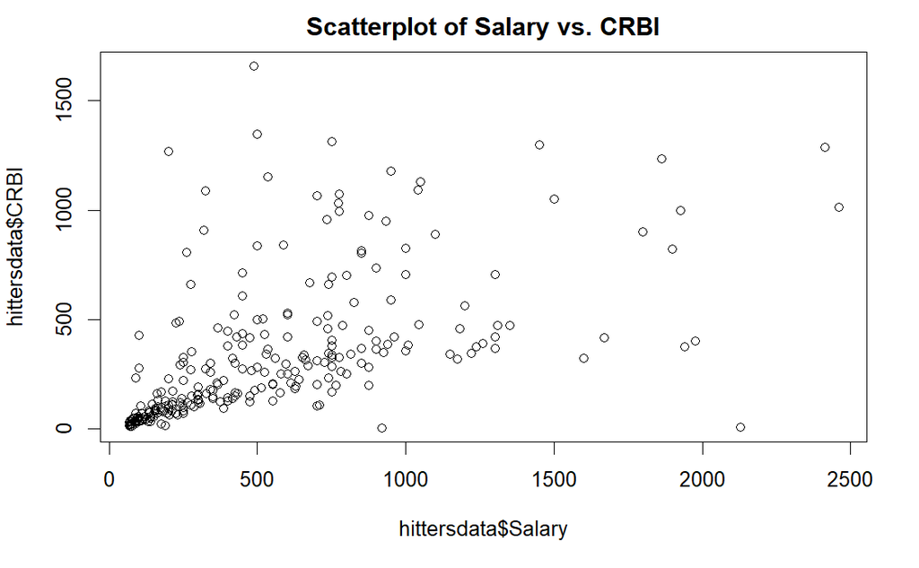

```r
plot(x = hittersdata$Salary , y = hittersdata$CRBI, main = "Scatterplot of Salary vs. CRBI")
```

```r
cor.test(Salary, CRBI)
```

```
    Pearson's product-moment correlation

data:  Salary and CRBI
t = 11.12, df = 261, p-value < 2.2e-16
alternative hypothesis: true correlation is not equal to 0
95 percent confidence interval:
 0.4788475 0.6437735
sample estimates:
      cor
0.5669657
```

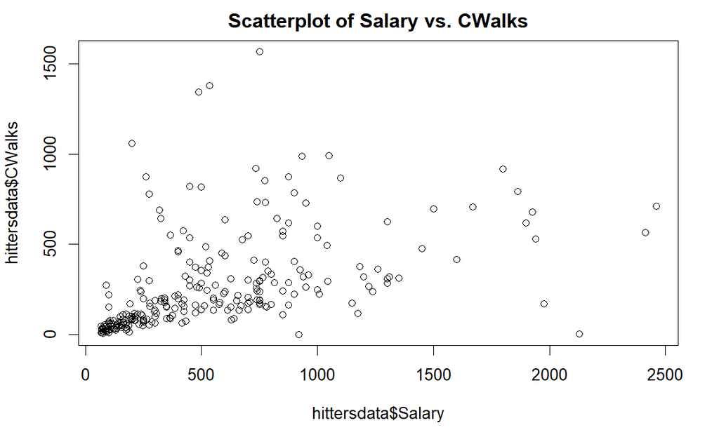

```r
plot(x = hittersdata$Salary , y = hittersdata$CWalks, main = "Scatterplot of Salary vs. CWalks")
```

```r
cor.test(Salary, CWalks)
```

```
    Pearson's product-moment correlation

data:  Salary and CWalks
t = 9.0768, df = 261, p-value < 2.2e-16
alternative hypothesis: true correlation is not equal to 0
95 percent confidence interval:
 0.3920960 0.5766158
sample estimates:
     cor
0.489822
```

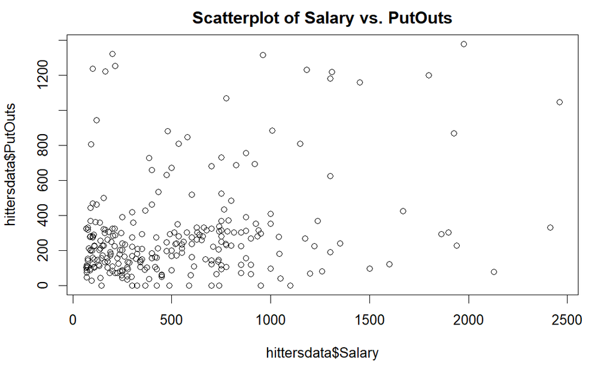

```r
plot(x = hittersdata$Salary , y = hittersdata$PutOuts, main = "Scatterplot of Salary vs. PutOuts")
```

```r
cor.test(Salary, PutOuts)
```

```
    Pearson's product-moment correlation

data:  Salary and PutOuts
t = 5.0896, df = 261, p-value = 6.871e-07
alternative hypothesis: true correlation is not equal to 0
95 percent confidence interval:
 0.1862946 0.4066570
sample estimates:
      cor
0.3004804
```

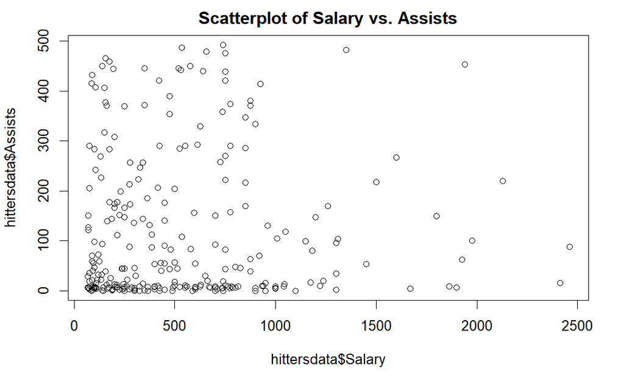

```r
plot(x = hittersdata$Salary , y = hittersdata$Assists, main = "Scatterplot of Salary vs. Assists")
```

```r
cor.test(Salary, Assists)
```

```
    Pearson's product-moment correlation

data:  Salary and Assists
t = 0.41107, df = 261, p-value = 0.6814
alternative hypothesis: true correlation is not equal to 0
95 percent confidence interval:
 -0.09581534  0.14594380
sample estimates:
       cor
0.02543614
```

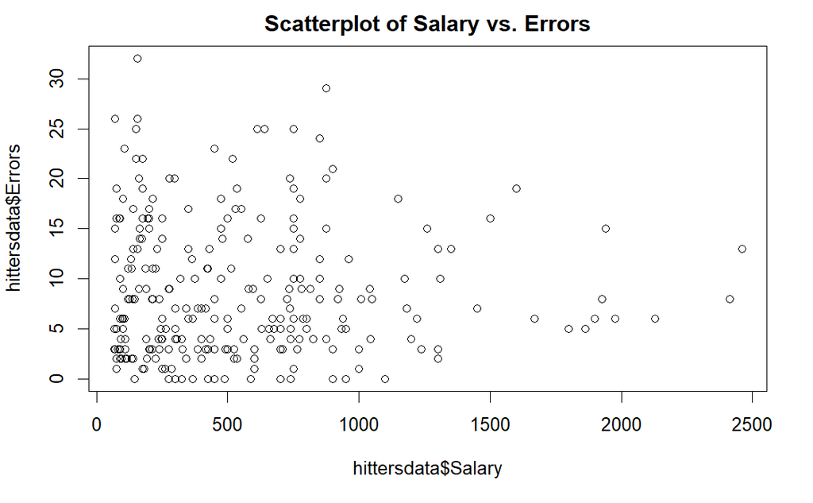

```r
plot(x = hittersdata$Salary , y = hittersdata$Errors, main = "Scatterplot of Salary vs. Errors")
```

```r
cor.test(Salary, Errors)
```

```
    Pearson's product-moment correlation

data:  Salary and Errors
t = -0.087252, df = 261, p-value = 0.9305
alternative hypothesis: true correlation is not equal to 0
95 percent confidence interval:
 -0.1262749  0.1156315
sample estimates:
         cor
-0.005400702
```

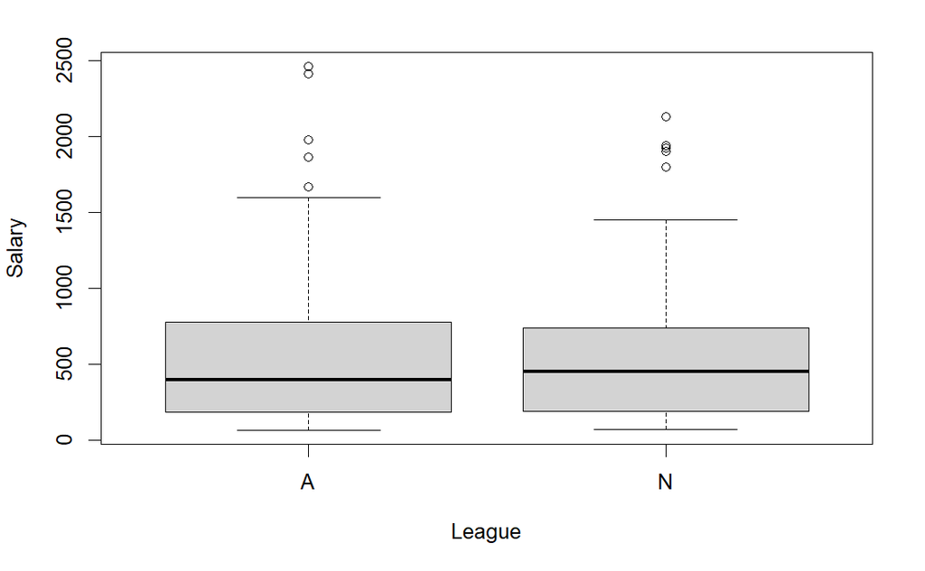

```r
plot(Salary~League)
```

```r
t.test(Salary~League)
```

```
    Welch Two Sample t-test

data:  Salary by League
t = 0.23157, df = 260.26, p-value = 0.8171
alternative hypothesis: true difference in means between group A and group N is not equal to 0
95 percent confidence interval:
 -96.66039 122.42448
sample estimates:
mean in group A mean in group N
       541.9995        529.1175
```

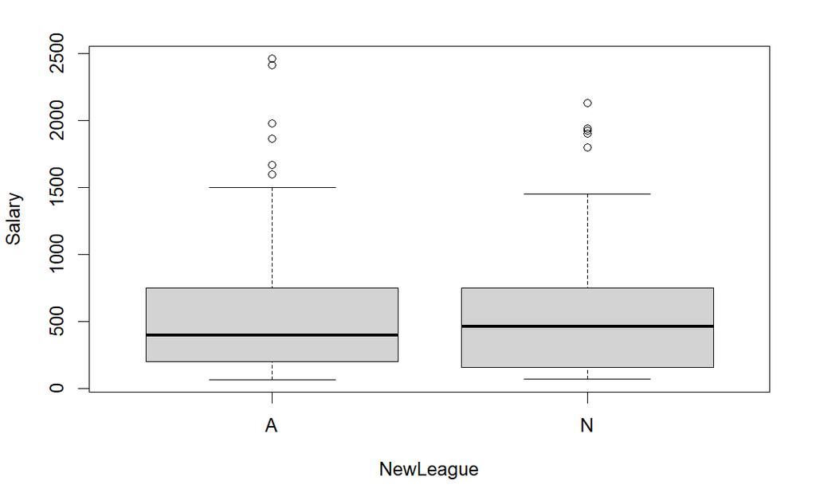

```r
plot(Salary~NewLeague)
```

```r
t.test(Salary~NewLeague)
```

```
    Welch Two Sample t-test

data:  Salary by NewLeague
t = 0.045921, df = 258.07, p-value = 0.9634
alternative hypothesis: true difference in means between group A and group N is not equal to 0
95 percent confidence interval:
 -107.1832  112.3016
sample estimates:
mean in group A mean in group N
       537.1130        534.5539
```

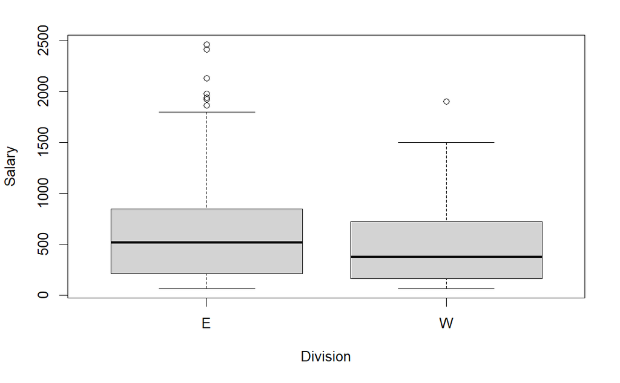

```r
plot(Salary~Division)
```

```r
t.test(Salary~Division)
```

```
    Welch Two Sample t-test

data:  Salary by Division
t = 3.145, df = 218.46, p-value = 0.001892
alternative hypothesis: true difference in means between group E and group W is not equal to 0
95 percent confidence interval:
  64.73206 282.05692
sample estimates:
mean in group E mean in group W
       624.2714        450.8769
```

ans:predictors-PutOuts, Cwalks, CRBI, CHmRun,CHits, CAtBat,years,Walks, RBI, Runs, HmRun,Hits, AtBat have moderate correlation with Salary.

```r
summary(hittersdata)
```

[output not shown]

5)Use Caret’s “createDataPartition” method as follows to partition the dataset into hitters_train, and hitters_test (use 90% for training and 10% for testing)

```r
set.seed(1)

library(caret)
inTrain = createDataPartition(hittersdata$Salary, p=0.9, list=FALSE)
hitters_train = hittersdata[inTrain,]
hitters_test = hittersdata[-inTrain,-19]
hitters_test_labels = hittersdata[-inTrain,19]
```

6)Neural networks do not accept categorical variables and we must encode the categorical variables before training the network. All the categorical variables in this dataset are binary ( i.e., have two levels) so you can encode them by simply using ifelse function to convert each to a numeric variable with two values 0 and 1.

```r
hitters_train$League= ifelse(hitters_train$League== "N", 0,1)
hitters_train$Division= ifelse(hitters_train$Division== "W", 0,1)
hitters_train$NewLeague= ifelse(hitters_train$NewLeague== "N", 0,1)
str(hitters_train)
```

```
'data.frame':   239 obs. of  20 variables:
 $ AtBat    : int  315 479 496 321 594 185 298 401 574 202 ...
 $ Hits     : int  81 130 141 87 169 37 73 92 159 53 ...
 $ HmRun    : int  7 18 20 10 4 1 0 17 21 4 ...
 $ Runs     : int  24 66 65 39 74 23 24 49 107 31 ...
 $ RBI      : int  38 72 78 42 51 8 24 66 75 26 ...
 $ Walks    : int  39 76 37 30 35 21 7 65 59 27 ...
 $ Years    : int  14 3 11 2 11 2 3 13 10 9 ...
 $ CAtBat   : int  3449 1624 5628 396 4408 214 509 5206 4631 1876 ...
 $ CHits    : int  835 457 1575 101 1133 42 108 1332 1300 467 ...
 $ CHmRun   : int  69 63 225 12 19 1 0 253 90 15 ...
 $ CRuns    : int  321 224 828 48 501 30 41 784 702 192 ...
 $ CRBI     : int  414 266 838 46 336 9 37 890 504 186 ...
 $ CWalks   : int  375 263 354 33 194 24 12 866 488 161 ...
 $ League   : num  0 1 0 0 1 0 1 1 1 0 ...
 $ Division : num  0 0 1 1 0 1 0 1 1 0 ...
 $ PutOuts  : int  632 880 200 805 282 76 121 0 238 304 ...
 $ Assists  : int  43 82 11 40 421 127 283 0 445 45 ...
 $ Errors   : int  10 14 3 4 25 7 9 0 22 11 ...
 $ Salary   : num  475 480 500 91.5 750 ...
 $ NewLeague: num  0 1 0 0 1 1 1 1 1 0 ...
 - attr(*, "na.action")= 'omit' Named int [1:59] 1 16 19 23 31 33 37 39 40 42 ...
  ..- attr(*, "names")= chr [1:59] "1" "16" "19" "23" ...
```

7)Replace the salary column with log(salary) where log is the logarithm function. This will be the attribute we want to predict.

```r
hitters_train$Salary = log(hitters_train$Salary)
str(hitters_train)
```

```
'data.frame':   239 obs. of  20 variables:
 $ AtBat    : int  315 479 496 321 594 185 298 401 574 202 ...
 $ Hits     : int  81 130 141 87 169 37 73 92 159 53 ...
 $ HmRun    : int  7 18 20 10 4 1 0 17 21 4 ...
 $ Runs     : int  24 66 65 39 74 23 24 49 107 31 ...
 $ RBI      : int  38 72 78 42 51 8 24 66 75 26 ...
 $ Walks    : int  39 76 37 30 35 21 7 65 59 27 ...
 $ Years    : int  14 3 11 2 11 2 3 13 10 9 ...
 $ CAtBat   : int  3449 1624 5628 396 4408 214 509 5206 4631 1876 ...
 $ CHits    : int  835 457 1575 101 1133 42 108 1332 1300 467 ...
 $ CHmRun   : int  69 63 225 12 19 1 0 253 90 15 ...
 $ CRuns    : int  321 224 828 48 501 30 41 784 702 192 ...
 $ CRBI     : int  414 266 838 46 336 9 37 890 504 186 ...
 $ CWalks   : int  375 263 354 33 194 24 12 866 488 161 ...
 $ League   : num  0 1 0 0 1 0 1 1 1 0 ...
 $ Division : num  0 0 1 1 0 1 0 1 1 0 ...
 $ PutOuts  : int  632 880 200 805 282 76 121 0 238 304 ...
 $ Assists  : int  43 82 11 40 421 127 283 0 445 45 ...
 $ Errors   : int  10 14 3 4 25 7 9 0 22 11 ...
 $ Salary   : num  6.16 6.17 6.21 4.52 6.62 ...
 $ NewLeague: num  0 1 0 0 1 1 1 1 1 0 ...
 - attr(*, "na.action")= 'omit' Named int [1:59] 1 16 19 23 31 33 37 39 40 42 ...
  ..- attr(*, "names")= chr [1:59] "1" "16" "19" "23" ...
```

8)Set.seed(1) and further divide the hitters_train data into 90% training and 10% validation using Caret’s “CreateDataPartition” function.

```r
set.seed(1)
intrain1= createDataPartition(hitters_train$Salary, p=0.9, list= FALSE)
hitters_train_x= hitters_train[intrain1, -19]
hitters_train_y= hitters_train[intrain1, 19]

hitters_val_x= hitters_train[intrain1, -19]
hitters_val_y= hitters_train[intrain1, 19]
str(hitters_train_x)
```

```
'data.frame':   216 obs. of  19 variables:
 $ AtBat    : int  315 479 496 321 594 185 298 401 574 202 ...
 $ Hits     : int  81 130 141 87 169 37 73 92 159 53 ...
 $ HmRun    : int  7 18 20 10 4 1 0 17 21 4 ...
 $ Runs     : int  24 66 65 39 74 23 24 49 107 31 ...
 $ RBI      : int  38 72 78 42 51 8 24 66 75 26 ...
 $ Walks    : int  39 76 37 30 35 21 7 65 59 27 ...
 $ Years    : int  14 3 11 2 11 2 3 13 10 9 ...
 $ CAtBat   : int  3449 1624 5628 396 4408 214 509 5206 4631 1876 ...
 $ CHits    : int  835 457 1575 101 1133 42 108 1332 1300 467 ...
 $ CHmRun   : int  69 63 225 12 19 1 0 253 90 15 ...
 $ CRuns    : int  321 224 828 48 501 30 41 784 702 192 ...
 $ CRBI     : int  414 266 838 46 336 9 37 890 504 186 ...
 $ CWalks   : int  375 263 354 33 194 24 12 866 488 161 ...
 $ League   : num  0 1 0 0 1 0 1 1 1 0 ...
 $ Division : num  0 0 1 1 0 1 0 1 1 0 ...
 $ PutOuts  : int  632 880 200 805 282 76 121 0 238 304 ...
 $ Assists  : int  43 82 11 40 421 127 283 0 445 45 ...
 $ Errors   : int  10 14 3 4 25 7 9 0 22 11 ...
 $ NewLeague: num  0 1 0 0 1 1 1 1 1 0 ...
```

```r
str(hitters_train_y)
```

```
 num [1:216] 6.16 6.17 6.21 4.52 6.62 ...
```

9)Scale the numeric attributes in the training data (except for the outcome variable, Salary). Use the column means and column standard deviations from the training data to scale both the validation and test data.

```r
numeric_cols=c("AtBat","Hits","HmRun","Runs","RBI","Walks","Years","CAtBat","CHits","CHmRun","CRuns","CRBI","CWalks","PutOuts","Assists","Errors")

col_means_train<-attr(scale(hitters_train_x[,numeric_cols]), "scaled:center")
col_stddevs_train<-attr( scale(hitters_train_x[,numeric_cols]), "scaled:scale")
hitters_train_x[numeric_cols]= scale(hitters_train_x[numeric_cols])
hitters_val_x[numeric_cols]<-scale(hitters_val_x[numeric_cols], center = col_means_train, scale = col_stddevs_train)
```

```r
categorical_cols=hitters_train_x[c("League","Division","NewLeague")]
hnum=as.data.frame(hitters_train_x[numeric_cols])
str(hnum)
```

```
'data.frame':   216 obs. of  16 variables:
 $ AtBat  : num  -0.571 0.533 0.647 -0.531 1.307 ...
 $ Hits   : num  -0.571 0.512 0.755 -0.438 1.374 ...
 $ HmRun  : num  -0.505 0.78 1.013 -0.155 -0.856 ...
 $ Runs   : num  -1.19 0.497 0.457 -0.588 0.819 ...
 $ RBI    : num  -0.51199 0.81104 1.04451 -0.35634 -0.00613 ...
 $ Walks  : num  -0.078 1.635 -0.171 -0.495 -0.263 ...
 $ Years  : num  1.476 -0.892 0.83 -1.107 0.83 ...
 $ CAtBat : num  0.395 -0.438 1.389 -0.998 0.832 ...
 $ CHits  : num  0.219 -0.396 1.422 -0.975 0.703 ...
 $ CHmRun : num  -0.00247 -0.07368 1.84894 -0.67895 -0.59587 ...
 $ CRuns  : num  -0.0903 -0.3997 1.5271 -0.9612 0.4839 ...
 $ CRBI   : num  0.2745 -0.1853 1.5917 -0.8688 0.0321 ...
 $ CWalks : num  0.4787 0.0395 0.3964 -0.8624 -0.231 ...
 $ PutOuts: num  1.33 2.2645 -0.2978 1.9819 0.0112 ...
 $ Assists: num  -0.505 -0.228 -0.732 -0.526 2.175 ...
 $ Errors : num  0.268 0.899 -0.838 -0.68 2.636 ...
```

```r
hittersnewdata=cbind(hnum,categorical_cols)
str(hittersnewdata)
```

```
'data.frame':   216 obs. of  19 variables:
 $ AtBat    : num  -0.571 0.533 0.647 -0.531 1.307 ...
 $ Hits     : num  -0.571 0.512 0.755 -0.438 1.374 ...
 $ HmRun    : num  -0.505 0.78 1.013 -0.155 -0.856 ...
 $ Runs     : num  -1.19 0.497 0.457 -0.588 0.819 ...
 $ RBI      : num  -0.51199 0.81104 1.04451 -0.35634 -0.00613 ...
 $ Walks    : num  -0.078 1.635 -0.171 -0.495 -0.263 ...
 $ Years    : num  1.476 -0.892 0.83 -1.107 0.83 ...
 $ CAtBat   : num  0.395 -0.438 1.389 -0.998 0.832 ...
 $ CHits    : num  0.219 -0.396 1.422 -0.975 0.703 ...
 $ CHmRun   : num  -0.00247 -0.07368 1.84894 -0.67895 -0.59587 ...
 $ CRuns    : num  -0.0903 -0.3997 1.5271 -0.9612 0.4839 ...
 $ CRBI     : num  0.2745 -0.1853 1.5917 -0.8688 0.0321 ...
 $ CWalks   : num  0.4787 0.0395 0.3964 -0.8624 -0.231 ...
 $ PutOuts  : num  1.33 2.2645 -0.2978 1.9819 0.0112 ...
 $ Assists  : num  -0.505 -0.228 -0.732 -0.526 2.175 ...
 $ Errors   : num  0.268 0.899 -0.838 -0.68 2.636 ...
 $ League   : num  0 1 0 0 1 0 1 1 1 0 ...
 $ Division : num  0 0 1 1 0 1 0 1 1 0 ...
 $ NewLeague: num  0 1 0 0 1 1 1 1 1 0 ...
```

```r
library(keras)
model1 <-keras_model_sequential() %>%
layer_dense(units = 16, activation = "relu", input_shape= dim(hittersnewdata)[2]) %>%
  layer_dense(units = 16,activation="relu" ) %>%
layer_dense(units = 1)
```

```r
model1
```

```r
model1 %>% compile(
loss = "mse",
optimizer = "adam")
model1
```

```
Model: "sequential_1"
__________________________________________________________________________________________
 Layer (type)                           Output Shape                        Param #
==========================================================================================
 dense_5 (Dense)                        (None, 16)                          320

 dense_4 (Dense)                        (None, 16)                          272

 dense_3 (Dense)                        (None, 1)                           17

==========================================================================================
Total params: 609
Trainable params: 609
Non-trainable params: 0
__________________________________________________________________________________________
```

```r
history <-model1 %>% fit(as.matrix(hittersnewdata),hitters_train_y,batch_size=50,epochs = 50, validation_data=list(as.matrix(hitters_val_x),hitters_val_y), verbose=2)
```

```
5/5 - 1s - loss: 33.2493 - val_loss: 32.2335 - 1s/epoch - 232ms/step
5/5 - 0s - loss: 31.6379 - val_loss: 30.7692 - 184ms/epoch - 37ms/step
5/5 - 0s - loss: 30.0349 - val_loss: 29.3092 - 189ms/epoch - 38ms/step
5/5 - 0s - loss: 28.4535 - val_loss: 27.8408 - 220ms/epoch - 44ms/step
5/5 - 0s - loss: 26.8358 - val_loss: 26.3615 - 202ms/epoch - 40ms/step
5/5 - 0s - loss: 25.2248 - val_loss: 24.8511 - 171ms/epoch - 34ms/step
5/5 - 0s - loss: 23.6019 - val_loss: 23.3190 - 174ms/epoch - 35ms/step
5/5 - 0s - loss: 21.9472 - val_loss: 21.7716 - 207ms/epoch - 41ms/step
5/5 - 0s - loss: 20.2859 - val_loss: 20.2135 - 173ms/epoch - 35ms/step
5/5 - 0s - loss: 18.6103 - val_loss: 18.6627 - 221ms/epoch - 44ms/step
5/5 - 0s - loss: 16.9617 - val_loss: 17.1217 - 190ms/epoch - 38ms/step
5/5 - 0s - loss: 15.3304 - val_loss: 15.6108 - 174ms/epoch - 35ms/step
5/5 - 0s - loss: 13.7325 - val_loss: 14.1512 - 191ms/epoch - 38ms/step
5/5 - 0s - loss: 12.2441 - val_loss: 12.7573 - 173ms/epoch - 35ms/step
5/5 - 0s - loss: 10.8330 - val_loss: 11.4727 - 189ms/epoch - 38ms/step
5/5 - 0s - loss: 9.5499 - val_loss: 10.3183 - 190ms/epoch - 38ms/step
5/5 - 0s - loss: 8.4468 - val_loss: 9.3050 - 190ms/epoch - 38ms/step
5/5 - 0s - loss: 7.4791 - val_loss: 8.4634 - 173ms/epoch - 35ms/step
5/5 - 0s - loss: 6.6973 - val_loss: 7.7879 - 190ms/epoch - 38ms/step
5/5 - 0s - loss: 6.0770 - val_loss: 7.2644 - 189ms/epoch - 38ms/step
5/5 - 0s - loss: 5.6275 - val_loss: 6.8640 - 206ms/epoch - 41ms/step
5/5 - 0s - loss: 5.2785 - val_loss: 6.5774 - 175ms/epoch - 35ms/step
5/5 - 0s - loss: 5.0211 - val_loss: 6.3758 - 189ms/epoch - 38ms/step
5/5 - 0s - loss: 4.8371 - val_loss: 6.2385 - 190ms/epoch - 38ms/step
5/5 - 0s - loss: 4.6651 - val_loss: 6.1347 - 186ms/epoch - 37ms/step
5/5 - 0s - loss: 4.5146 - val_loss: 6.0591 - 207ms/epoch - 41ms/step
5/5 - 0s - loss: 4.3661 - val_loss: 5.9968 - 190ms/epoch - 38ms/step
5/5 - 0s - loss: 4.2375 - val_loss: 5.9392 - 191ms/epoch - 38ms/step
5/5 - 0s - loss: 4.1102 - val_loss: 5.8919 - 175ms/epoch - 35ms/step
5/5 - 0s - loss: 3.9880 - val_loss: 5.8534 - 172ms/epoch - 34ms/step
5/5 - 0s - loss: 3.8724 - val_loss: 5.8151 - 189ms/epoch - 38ms/step
5/5 - 0s - loss: 3.7588 - val_loss: 5.7801 - 175ms/epoch - 35ms/step
5/5 - 0s - loss: 3.6428 - val_loss: 5.7521 - 175ms/epoch - 35ms/step
5/5 - 0s - loss: 3.5429 - val_loss: 5.7168 - 174ms/epoch - 35ms/step
5/5 - 0s - loss: 3.4448 - val_loss: 5.6883 - 175ms/epoch - 35ms/step
5/5 - 0s - loss: 3.3532 - val_loss: 5.6579 - 189ms/epoch - 38ms/step
5/5 - 0s - loss: 3.2700 - val_loss: 5.6311 - 175ms/epoch - 35ms/step
5/5 - 0s - loss: 3.1898 - val_loss: 5.5985 - 175ms/epoch - 35ms/step
5/5 - 0s - loss: 3.1121 - val_loss: 5.5735 - 206ms/epoch - 41ms/step
5/5 - 0s - loss: 3.0394 - val_loss: 5.5454 - 174ms/epoch - 35ms/step
5/5 - 0s - loss: 2.9716 - val_loss: 5.5351 - 188ms/epoch - 38ms/step
5/5 - 0s - loss: 2.9048 - val_loss: 5.5191 - 188ms/epoch - 38ms/step
5/5 - 0s - loss: 2.8315 - val_loss: 5.4960 - 173ms/epoch - 35ms/step
5/5 - 0s - loss: 2.7620 - val_loss: 5.4748 - 174ms/epoch - 35ms/step
5/5 - 0s - loss: 2.6969 - val_loss: 5.4519 - 173ms/epoch - 35ms/step
5/5 - 0s - loss: 2.6346 - val_loss: 5.4218 - 174ms/epoch - 35ms/step
5/5 - 0s - loss: 2.5713 - val_loss: 5.3917 - 173ms/epoch - 35ms/step
5/5 - 0s - loss: 2.5124 - val_loss: 5.3676 - 190ms/epoch - 38ms/step
5/5 - 0s - loss: 2.4513 - val_loss: 5.3497 - 175ms/epoch - 35ms/step
5/5 - 0s - loss: 2.3974 - val_loss: 5.3248 - 175ms/epoch - 35ms/step
```

```r
library(tfruns)
problem2runs=tuning_run("hitters_hyperparameters.R",
           flags=list(
             learning_rate=c(0.1,0.01,0.001,0.0001),
             batch_size=c(16,16,1),
             activation_function=c("relu","relu"),
             units1=c(16,32,64,128),
             units2=c(16,32,64,128)
           ),
           sample=0.01
         )
```

```
384 total combinations of flags
(sampled to 4 combinations)
```

```r
Y
```

```
Training run 1/4 (flags = list(0.01, 16, "relu", 32, 64))
Using run directory runs/2022-04-07T04-20-25Z
```

```
> FLAGS <-flags(
+   flag_numeric("batch_size", 50),
+   flag_numeric("units1", 16),
+   flag_numeric("units2", 16),
+   flag_string("activation_funct ..." ... [TRUNCATED]

> library(keras)

> model1 <-keras_model_sequential() %>%
+   layer_dense(units = FLAGS$units1, activation = FLAGS$activation_function,
+               input_shape=dim( .... [TRUNCATED]

> model1 %>% compile(loss = "mse",optimizer =optimizer_adam(learning_rate=FLAGS$learning_rate))

> model1 %>% fit(as.matrix(hittersnewdata),
+               hitters_train_y,
+               batch_size=FLAGS$batch_size,
+               epochs = 50, .... [TRUNCATED]
```

```
WARNING:tensorflow:Callback method `on_train_batch_end` is slow compared to the batch time (batch time: 0.0012s vs `on_train_batch_end` time: 0.0026s). Check your callbacks.
```

```
14/14 - 1s - loss: 11.4122 - val_loss: 3.9131 - 1s/epoch - 79ms/step
14/14 - 0s - loss: 2.8650 - val_loss: 3.6977 - 220ms/epoch - 16ms/step
14/14 - 0s - loss: 1.7110 - val_loss: 3.3995 - 232ms/epoch - 17ms/step
14/14 - 0s - loss: 1.1332 - val_loss: 2.1676 - 220ms/epoch - 16ms/step
14/14 - 0s - loss: 0.9316 - val_loss: 1.7064 - 222ms/epoch - 16ms/step
14/14 - 0s - loss: 0.7635 - val_loss: 1.2508 - 208ms/epoch - 15ms/step
14/14 - 0s - loss: 0.5894 - val_loss: 1.1842 - 221ms/epoch - 16ms/step
14/14 - 0s - loss: 0.5031 - val_loss: 1.0968 - 221ms/epoch - 16ms/step
14/14 - 0s - loss: 0.4599 - val_loss: 1.2012 - 269ms/epoch - 19ms/step
14/14 - 0s - loss: 0.3941 - val_loss: 1.0902 - 221ms/epoch - 16ms/step
14/14 - 0s - loss: 0.4059 - val_loss: 1.1968 - 224ms/epoch - 16ms/step
14/14 - 0s - loss: 0.3647 - val_loss: 1.0866 - 221ms/epoch - 16ms/step
14/14 - 0s - loss: 0.3491 - val_loss: 1.3128 - 221ms/epoch - 16ms/step
14/14 - 0s - loss: 0.4065 - val_loss: 1.6209 - 222ms/epoch - 16ms/step
14/14 - 0s - loss: 0.4931 - val_loss: 1.6349 - 222ms/epoch - 16ms/step
14/14 - 0s - loss: 0.4980 - val_loss: 1.7047 - 223ms/epoch - 16ms/step
14/14 - 0s - loss: 0.3691 - val_loss: 1.5450 - 206ms/epoch - 15ms/step
14/14 - 0s - loss: 0.3288 - val_loss: 1.2851 - 206ms/epoch - 15ms/step
14/14 - 0s - loss: 0.2785 - val_loss: 1.4295 - 223ms/epoch - 16ms/step
14/14 - 0s - loss: 0.4102 - val_loss: 1.5224 - 205ms/epoch - 15ms/step
14/14 - 0s - loss: 0.3212 - val_loss: 1.4282 - 222ms/epoch - 16ms/step
14/14 - 0s - loss: 0.2803 - val_loss: 1.2484 - 224ms/epoch - 16ms/step
14/14 - 0s - loss: 0.2333 - val_loss: 1.2880 - 220ms/epoch - 16ms/step
14/14 - 0s - loss: 0.2095 - val_loss: 1.3929 - 222ms/epoch - 16ms/step
14/14 - 0s - loss: 0.1571 - val_loss: 1.4449 - 222ms/epoch - 16ms/step
14/14 - 0s - loss: 0.1559 - val_loss: 1.0113 - 204ms/epoch - 15ms/step
14/14 - 0s - loss: 0.1779 - val_loss: 1.1701 - 223ms/epoch - 16ms/step
14/14 - 0s - loss: 0.1461 - val_loss: 1.7191 - 205ms/epoch - 15ms/step
14/14 - 0s - loss: 0.1420 - val_loss: 1.1766 - 223ms/epoch - 16ms/step
14/14 - 0s - loss: 0.1178 - val_loss: 1.5006 - 218ms/epoch - 16ms/step
14/14 - 0s - loss: 0.1083 - val_loss: 1.2312 - 224ms/epoch - 16ms/step
14/14 - 0s - loss: 0.1061 - val_loss: 1.0808 - 204ms/epoch - 15ms/step
14/14 - 0s - loss: 0.1655 - val_loss: 1.4458 - 207ms/epoch - 15ms/step
14/14 - 0s - loss: 0.1122 - val_loss: 1.2095 - 236ms/epoch - 17ms/step
14/14 - 0s - loss: 0.0908 - val_loss: 1.0399 - 220ms/epoch - 16ms/step
14/14 - 0s - loss: 0.0835 - val_loss: 1.2693 - 224ms/epoch - 16ms/step
14/14 - 0s - loss: 0.0913 - val_loss: 1.2427 - 238ms/epoch - 17ms/step
14/14 - 0s - loss: 0.0847 - val_loss: 1.2570 - 208ms/epoch - 15ms/step
14/14 - 0s - loss: 0.0781 - val_loss: 1.2912 - 217ms/epoch - 15ms/step
14/14 - 0s - loss: 0.1050 - val_loss: 1.3149 - 220ms/epoch - 16ms/step
14/14 - 0s - loss: 0.1054 - val_loss: 1.2378 - 223ms/epoch - 16ms/step
14/14 - 0s - loss: 0.0955 - val_loss: 1.2522 - 221ms/epoch - 16ms/step
14/14 - 0s - loss: 0.0815 - val_loss: 1.2413 - 223ms/epoch - 16ms/step
14/14 - 0s - loss: 0.0698 - val_loss: 1.1426 - 221ms/epoch - 16ms/step
14/14 - 0s - loss: 0.0894 - val_loss: 0.9213 - 235ms/epoch - 17ms/step
14/14 - 0s - loss: 0.0835 - val_loss: 1.1565 - 226ms/epoch - 16ms/step
14/14 - 0s - loss: 0.0710 - val_loss: 1.3022 - 223ms/epoch - 16ms/step
14/14 - 0s - loss: 0.0573 - val_loss: 1.2291 - 237ms/epoch - 17ms/step
14/14 - 0s - loss: 0.0722 - val_loss: 1.1395 - 207ms/epoch - 15ms/step
14/14 - 0s - loss: 0.0765 - val_loss: 1.3899 - 206ms/epoch - 15ms/step
```

```
Run completed: runs/2022-04-07T04-20-25Z

Training run 2/4 (flags = list(0.1, 16, "relu", 32, 32))
Using run directory runs/2022-04-07T04-22-22Z
```

```
> FLAGS <-flags(
+   flag_numeric("batch_size", 50),
+   flag_numeric("units1", 16),
+   flag_numeric("units2", 16),
+   flag_string("activation_funct ..." ... [TRUNCATED]

> library(keras)

> model1 <-keras_model_sequential() %>%
+   layer_dense(units = FLAGS$units1, activation = FLAGS$activation_function,
+               input_shape=dim( .... [TRUNCATED]

> model1 %>% compile(loss = "mse",optimizer =optimizer_adam(learning_rate=FLAGS$learning_rate))

> model1 %>% fit(as.matrix(hittersnewdata),
+               hitters_train_y,
+               batch_size=FLAGS$batch_size,
+               epochs = 50, .... [TRUNCATED]
```

```
WARNING:tensorflow:Callback method `on_train_batch_end` is slow compared to the batch time (batch time: 0.0012s vs `on_train_batch_end` time: 0.0022s). Check your callbacks.
```

```
14/14 - 1s - loss: 14.1200 - val_loss: 6.5209 - 1s/epoch - 79ms/step
14/14 - 0s - loss: 4.3400 - val_loss: 4.3607 - 218ms/epoch - 16ms/step
14/14 - 0s - loss: 1.9189 - val_loss: 4.0472 - 223ms/epoch - 16ms/step
14/14 - 0s - loss: 1.3323 - val_loss: 2.2133 - 224ms/epoch - 16ms/step
14/14 - 0s - loss: 0.8487 - val_loss: 1.6999 - 215ms/epoch - 15ms/step
14/14 - 0s - loss: 1.0621 - val_loss: 1.7970 - 208ms/epoch - 15ms/step
14/14 - 0s - loss: 0.8301 - val_loss: 1.2673 - 239ms/epoch - 17ms/step
14/14 - 0s - loss: 0.6111 - val_loss: 1.1221 - 239ms/epoch - 17ms/step
14/14 - 0s - loss: 0.5164 - val_loss: 1.1073 - 217ms/epoch - 15ms/step
14/14 - 0s - loss: 0.3524 - val_loss: 0.7095 - 206ms/epoch - 15ms/step
14/14 - 0s - loss: 0.3109 - val_loss: 0.6702 - 207ms/epoch - 15ms/step
14/14 - 0s - loss: 0.2659 - val_loss: 0.5714 - 236ms/epoch - 17ms/step
14/14 - 0s - loss: 0.3208 - val_loss: 0.8762 - 212ms/epoch - 15ms/step
14/14 - 0s - loss: 0.3742 - val_loss: 0.7310 - 217ms/epoch - 15ms/step
14/14 - 0s - loss: 0.5513 - val_loss: 0.6644 - 208ms/epoch - 15ms/step
14/14 - 0s - loss: 0.3429 - val_loss: 0.8668 - 205ms/epoch - 15ms/step
14/14 - 0s - loss: 0.3191 - val_loss: 0.9912 - 220ms/epoch - 16ms/step
14/14 - 0s - loss: 0.2848 - val_loss: 0.5783 - 222ms/epoch - 16ms/step
14/14 - 0s - loss: 0.2224 - val_loss: 0.4493 - 222ms/epoch - 16ms/step
14/14 - 0s - loss: 0.1877 - val_loss: 0.4938 - 208ms/epoch - 15ms/step
14/14 - 0s - loss: 0.1622 - val_loss: 0.4829 - 223ms/epoch - 16ms/step
14/14 - 0s - loss: 0.2356 - val_loss: 0.4187 - 223ms/epoch - 16ms/step
14/14 - 0s - loss: 0.1653 - val_loss: 0.3881 - 220ms/epoch - 16ms/step
14/14 - 0s - loss: 0.1543 - val_loss: 0.5028 - 224ms/epoch - 16ms/step
14/14 - 0s - loss: 0.1277 - val_loss: 0.4716 - 223ms/epoch - 16ms/step
14/14 - 0s - loss: 0.1296 - val_loss: 0.4934 - 218ms/epoch - 16ms/step
14/14 - 0s - loss: 0.1347 - val_loss: 0.4855 - 207ms/epoch - 15ms/step
14/14 - 0s - loss: 0.1164 - val_loss: 0.6090 - 206ms/epoch - 15ms/step
14/14 - 0s - loss: 0.2272 - val_loss: 0.6944 - 224ms/epoch - 16ms/step
14/14 - 0s - loss: 0.1603 - val_loss: 0.6612 - 204ms/epoch - 15ms/step
14/14 - 0s - loss: 0.1477 - val_loss: 0.5624 - 224ms/epoch - 16ms/step
14/14 - 0s - loss: 0.1929 - val_loss: 0.8226 - 221ms/epoch - 16ms/step
14/14 - 0s - loss: 0.2486 - val_loss: 0.6759 - 206ms/epoch - 15ms/step
14/14 - 0s - loss: 0.2186 - val_loss: 0.8858 - 223ms/epoch - 16ms/step
14/14 - 0s - loss: 0.1663 - val_loss: 0.5284 - 237ms/epoch - 17ms/step
14/14 - 0s - loss: 0.1351 - val_loss: 0.6069 - 222ms/epoch - 16ms/step
14/14 - 0s - loss: 0.1322 - val_loss: 0.4828 - 220ms/epoch - 16ms/step
14/14 - 0s - loss: 0.1774 - val_loss: 0.5488 - 226ms/epoch - 16ms/step
14/14 - 0s - loss: 0.1651 - val_loss: 0.8314 - 221ms/epoch - 16ms/step
14/14 - 0s - loss: 0.1277 - val_loss: 0.5244 - 220ms/epoch - 16ms/step
14/14 - 0s - loss: 0.1177 - val_loss: 0.5871 - 219ms/epoch - 16ms/step
14/14 - 0s - loss: 0.0902 - val_loss: 0.4645 - 223ms/epoch - 16ms/step
14/14 - 0s - loss: 0.0845 - val_loss: 0.5612 - 239ms/epoch - 17ms/step
14/14 - 0s - loss: 0.0872 - val_loss: 0.4376 - 219ms/epoch - 16ms/step
14/14 - 0s - loss: 0.1184 - val_loss: 0.5187 - 221ms/epoch - 16ms/step
14/14 - 0s - loss: 0.1148 - val_loss: 0.6780 - 205ms/epoch - 15ms/step
14/14 - 0s - loss: 0.0773 - val_loss: 0.5346 - 209ms/epoch - 15ms/step
14/14 - 0s - loss: 0.0672 - val_loss: 0.5386 - 221ms/epoch - 16ms/step
14/14 - 0s - loss: 0.0725 - val_loss: 0.4954 - 224ms/epoch - 16ms/step
14/14 - 0s - loss: 0.0916 - val_loss: 0.7070 - 218ms/epoch - 16ms/step
```

```
Run completed: runs/2022-04-07T04-22-22Z

Training run 3/4 (flags = list(0.1, 16, "relu", 128, 16))
Using run directory runs/2022-04-07T04-22-49Z
```

```
> FLAGS <-flags(
+   flag_numeric("batch_size", 50),
+   flag_numeric("units1", 16),
+   flag_numeric("units2", 16),
+   flag_string("activation_funct ..." ... [TRUNCATED]

> library(keras)

> model1 <-keras_model_sequential() %>%
+   layer_dense(units = FLAGS$units1, activation = FLAGS$activation_function,
+               input_shape=dim( .... [TRUNCATED]

> model1 %>% compile(loss = "mse",optimizer =optimizer_adam(learning_rate=FLAGS$learning_rate))

> model1 %>% fit(as.matrix(hittersnewdata),
+               hitters_train_y,
+               batch_size=FLAGS$batch_size,
+               epochs = 50, .... [TRUNCATED]
```

```
WARNING:tensorflow:Callback method `on_train_batch_end` is slow compared to the batch time (batch time: 0.0012s vs `on_train_batch_end` time: 0.0054s). Check your callbacks.
```

```
14/14 - 1s - loss: 63.4410 - val_loss: 30.8223 - 1s/epoch - 82ms/step
14/14 - 0s - loss: 25.3216 - val_loss: 18.1440 - 234ms/epoch - 17ms/step
14/14 - 0s - loss: 15.5308 - val_loss: 9.3852 - 236ms/epoch - 17ms/step
14/14 - 0s - loss: 7.5675 - val_loss: 4.2576 - 234ms/epoch - 17ms/step
14/14 - 0s - loss: 2.8236 - val_loss: 4.1090 - 211ms/epoch - 15ms/step
14/14 - 0s - loss: 1.5807 - val_loss: 1.6458 - 224ms/epoch - 16ms/step
14/14 - 0s - loss: 0.9207 - val_loss: 1.6908 - 232ms/epoch - 17ms/step
14/14 - 0s - loss: 0.6799 - val_loss: 1.4238 - 236ms/epoch - 17ms/step
14/14 - 0s - loss: 0.5037 - val_loss: 1.4407 - 223ms/epoch - 16ms/step
14/14 - 0s - loss: 0.5094 - val_loss: 1.3979 - 231ms/epoch - 16ms/step
14/14 - 0s - loss: 0.4498 - val_loss: 1.2564 - 226ms/epoch - 16ms/step
14/14 - 0s - loss: 0.4160 - val_loss: 0.8814 - 219ms/epoch - 16ms/step
14/14 - 0s - loss: 0.3325 - val_loss: 0.8618 - 238ms/epoch - 17ms/step
14/14 - 0s - loss: 0.3465 - val_loss: 1.2324 - 223ms/epoch - 16ms/step
14/14 - 0s - loss: 0.3047 - val_loss: 0.8940 - 217ms/epoch - 16ms/step
14/14 - 0s - loss: 0.2978 - val_loss: 0.8180 - 233ms/epoch - 17ms/step
14/14 - 0s - loss: 0.2687 - val_loss: 0.8938 - 239ms/epoch - 17ms/step
14/14 - 0s - loss: 0.2769 - val_loss: 1.0843 - 258ms/epoch - 18ms/step
14/14 - 0s - loss: 0.2234 - val_loss: 0.8763 - 239ms/epoch - 17ms/step
14/14 - 0s - loss: 0.2234 - val_loss: 0.8889 - 244ms/epoch - 17ms/step
14/14 - 0s - loss: 0.1935 - val_loss: 0.9186 - 260ms/epoch - 19ms/step
14/14 - 0s - loss: 0.2442 - val_loss: 0.8411 - 276ms/epoch - 20ms/step
14/14 - 0s - loss: 0.1988 - val_loss: 0.7552 - 292ms/epoch - 21ms/step
14/14 - 0s - loss: 0.3644 - val_loss: 0.6948 - 260ms/epoch - 19ms/step
14/14 - 0s - loss: 0.2907 - val_loss: 0.6780 - 242ms/epoch - 17ms/step
14/14 - 0s - loss: 0.2350 - val_loss: 0.8183 - 217ms/epoch - 16ms/step
14/14 - 0s - loss: 0.2154 - val_loss: 0.8867 - 212ms/epoch - 15ms/step
14/14 - 0s - loss: 0.2295 - val_loss: 0.7287 - 224ms/epoch - 16ms/step
14/14 - 0s - loss: 0.2036 - val_loss: 0.6838 - 222ms/epoch - 16ms/step
14/14 - 0s - loss: 0.2343 - val_loss: 0.4843 - 225ms/epoch - 16ms/step
14/14 - 0s - loss: 0.1894 - val_loss: 0.7220 - 213ms/epoch - 15ms/step
14/14 - 0s - loss: 0.1889 - val_loss: 0.7272 - 237ms/epoch - 17ms/step
14/14 - 0s - loss: 0.2529 - val_loss: 0.6577 - 218ms/epoch - 16ms/step
14/14 - 0s - loss: 0.1850 - val_loss: 0.7088 - 211ms/epoch - 15ms/step
14/14 - 0s - loss: 0.2046 - val_loss: 0.7174 - 216ms/epoch - 15ms/step
14/14 - 0s - loss: 0.1464 - val_loss: 0.5854 - 217ms/epoch - 15ms/step
14/14 - 0s - loss: 0.1353 - val_loss: 0.8190 - 244ms/epoch - 17ms/step
14/14 - 0s - loss: 0.1697 - val_loss: 0.9339 - 239ms/epoch - 17ms/step
14/14 - 0s - loss: 0.1791 - val_loss: 0.6817 - 222ms/epoch - 16ms/step
14/14 - 0s - loss: 0.1524 - val_loss: 0.6610 - 233ms/epoch - 17ms/step
14/14 - 0s - loss: 0.2177 - val_loss: 0.6577 - 247ms/epoch - 18ms/step
14/14 - 0s - loss: 0.2346 - val_loss: 0.8527 - 257ms/epoch - 18ms/step
14/14 - 0s - loss: 0.1510 - val_loss: 0.6295 - 207ms/epoch - 15ms/step
14/14 - 0s - loss: 0.1705 - val_loss: 0.6728 - 325ms/epoch - 23ms/step
14/14 - 0s - loss: 0.1670 - val_loss: 0.5872 - 221ms/epoch - 16ms/step
14/14 - 0s - loss: 0.1709 - val_loss: 0.4969 - 226ms/epoch - 16ms/step
14/14 - 0s - loss: 0.1836 - val_loss: 0.5136 - 217ms/epoch - 16ms/step
14/14 - 0s - loss: 0.2072 - val_loss: 0.8908 - 239ms/epoch - 17ms/step
14/14 - 0s - loss: 0.2115 - val_loss: 0.6432 - 224ms/epoch - 16ms/step
14/14 - 0s - loss: 0.1953 - val_loss: 0.6065 - 231ms/epoch - 16ms/step
```

```
Run completed: runs/2022-04-07T04-22-49Z

Training run 4/4 (flags = list(0.001, 16, "relu", 32, 16))
Using run directory runs/2022-04-07T04-23-18Z
```

```
> FLAGS <-flags(
+   flag_numeric("batch_size", 50),
+   flag_numeric("units1", 16),
+   flag_numeric("units2", 16),
+   flag_string("activation_funct ..." ... [TRUNCATED]

> library(keras)

> model1 <-keras_model_sequential() %>%
+   layer_dense(units = FLAGS$units1, activation = FLAGS$activation_function,
+               input_shape=dim( .... [TRUNCATED]

> model1 %>% compile(loss = "mse",optimizer =optimizer_adam(learning_rate=FLAGS$learning_rate))

> model1 %>% fit(as.matrix(hittersnewdata),
+               hitters_train_y,
+               batch_size=FLAGS$batch_size,
+               epochs = 50, .... [TRUNCATED]
```

```
WARNING:tensorflow:Callback method `on_train_batch_end` is slow compared to the batch time (batch time: 0.0000s vs `on_train_batch_end` time: 0.0026s). Check your callbacks.
```

```
14/14 - 1s - loss: 39.2915 - val_loss: 35.4174 - 1s/epoch - 79ms/step
14/14 - 0s - loss: 31.6569 - val_loss: 28.5196 - 231ms/epoch - 16ms/step
14/14 - 0s - loss: 25.1008 - val_loss: 22.3741 - 239ms/epoch - 17ms/step
14/14 - 0s - loss: 19.0852 - val_loss: 16.6377 - 233ms/epoch - 17ms/step
14/14 - 0s - loss: 13.5683 - val_loss: 11.5098 - 212ms/epoch - 15ms/step
14/14 - 0s - loss: 9.0277 - val_loss: 7.6022 - 225ms/epoch - 16ms/step
14/14 - 0s - loss: 5.9185 - val_loss: 5.2706 - 234ms/epoch - 17ms/step
14/14 - 0s - loss: 4.4104 - val_loss: 4.3351 - 225ms/epoch - 16ms/step
14/14 - 0s - loss: 3.8354 - val_loss: 3.9845 - 209ms/epoch - 15ms/step
14/14 - 0s - loss: 3.5405 - val_loss: 3.7614 - 218ms/epoch - 16ms/step
14/14 - 0s - loss: 3.2382 - val_loss: 3.5644 - 233ms/epoch - 17ms/step
14/14 - 0s - loss: 2.9759 - val_loss: 3.4288 - 220ms/epoch - 16ms/step
14/14 - 0s - loss: 2.7632 - val_loss: 3.3264 - 210ms/epoch - 15ms/step
14/14 - 0s - loss: 2.5771 - val_loss: 3.2939 - 216ms/epoch - 15ms/step
14/14 - 0s - loss: 2.3849 - val_loss: 3.1910 - 233ms/epoch - 17ms/step
14/14 - 0s - loss: 2.2363 - val_loss: 3.0877 - 231ms/epoch - 17ms/step
14/14 - 0s - loss: 2.1017 - val_loss: 3.0297 - 218ms/epoch - 16ms/step
14/14 - 0s - loss: 1.9779 - val_loss: 3.0219 - 217ms/epoch - 15ms/step
14/14 - 0s - loss: 1.8676 - val_loss: 3.0185 - 220ms/epoch - 16ms/step
14/14 - 0s - loss: 1.7802 - val_loss: 3.0401 - 240ms/epoch - 17ms/step
14/14 - 0s - loss: 1.6936 - val_loss: 2.9843 - 213ms/epoch - 15ms/step
14/14 - 0s - loss: 1.6064 - val_loss: 2.9248 - 213ms/epoch - 15ms/step
14/14 - 0s - loss: 1.5280 - val_loss: 2.8964 - 240ms/epoch - 17ms/step
14/14 - 0s - loss: 1.4620 - val_loss: 2.8556 - 217ms/epoch - 16ms/step
14/14 - 0s - loss: 1.4021 - val_loss: 2.8429 - 247ms/epoch - 18ms/step
14/14 - 0s - loss: 1.3488 - val_loss: 2.7993 - 260ms/epoch - 19ms/step
14/14 - 0s - loss: 1.3009 - val_loss: 2.7429 - 320ms/epoch - 23ms/step
14/14 - 0s - loss: 1.2627 - val_loss: 2.6855 - 288ms/epoch - 21ms/step
14/14 - 0s - loss: 1.2070 - val_loss: 2.6705 - 250ms/epoch - 18ms/step
14/14 - 0s - loss: 1.1817 - val_loss: 2.6766 - 224ms/epoch - 16ms/step
14/14 - 0s - loss: 1.1352 - val_loss: 2.5673 - 226ms/epoch - 16ms/step
14/14 - 0s - loss: 1.0976 - val_loss: 2.4882 - 248ms/epoch - 18ms/step
14/14 - 0s - loss: 1.0715 - val_loss: 2.4659 - 233ms/epoch - 17ms/step
14/14 - 0s - loss: 1.0425 - val_loss: 2.3802 - 218ms/epoch - 16ms/step
14/14 - 0s - loss: 1.0273 - val_loss: 2.4232 - 226ms/epoch - 16ms/step
14/14 - 0s - loss: 0.9789 - val_loss: 2.3143 - 213ms/epoch - 15ms/step
14/14 - 0s - loss: 0.9564 - val_loss: 2.2705 - 224ms/epoch - 16ms/step
14/14 - 0s - loss: 0.9354 - val_loss: 2.2215 - 206ms/epoch - 15ms/step
14/14 - 0s - loss: 0.8929 - val_loss: 2.1851 - 229ms/epoch - 16ms/step
14/14 - 0s - loss: 0.8742 - val_loss: 2.1705 - 239ms/epoch - 17ms/step
14/14 - 0s - loss: 0.8513 - val_loss: 2.0973 - 219ms/epoch - 16ms/step
14/14 - 0s - loss: 0.8252 - val_loss: 2.0491 - 244ms/epoch - 17ms/step
14/14 - 0s - loss: 0.8040 - val_loss: 2.0036 - 219ms/epoch - 16ms/step
14/14 - 0s - loss: 0.7823 - val_loss: 1.9745 - 213ms/epoch - 15ms/step
14/14 - 0s - loss: 0.7630 - val_loss: 1.9151 - 218ms/epoch - 16ms/step
14/14 - 0s - loss: 0.7453 - val_loss: 1.8895 - 222ms/epoch - 16ms/step
14/14 - 0s - loss: 0.7222 - val_loss: 1.8434 - 223ms/epoch - 16ms/step
14/14 - 0s - loss: 0.7097 - val_loss: 1.7992 - 249ms/epoch - 18ms/step
14/14 - 0s - loss: 0.6875 - val_loss: 1.7792 - 293ms/epoch - 21ms/step
14/14 - 0s - loss: 0.6705 - val_loss: 1.7588 - 272ms/epoch - 19ms/step
```

```
Run completed: runs/2022-04-07T04-23-18Z
```

```r
problem2runs=problem2runs[order(problem2runs$metric_val_loss, decreasing=TRUE),]
problem2runs
```

```
Data frame: 4 x 23
```

|  | run_dir | metric_loss | metric_val_loss |
| --- | --- | --- | --- |
| 1 | runs/2022-04-07T04-23-18Z | 0.6705 | 1.7588 |
| 4 | runs/2022-04-07T04-20-25Z | 0.0765 | 1.3899 |
| 3 | runs/2022-04-07T04-22-22Z | 0.0916 | 0.7070 |
| 2 | runs/2022-04-07T04-22-49Z | 0.1953 | 0.6065 |

```
# ... with 20 more columns:
#   flag_batch_size, flag_units1, flag_units2, flag_activation_function,
#   flag_learning_rate, epochs, epochs_completed, metrics, model, loss_function,
#   optimizer, learning_rate, script, start, end, completed, output, source_code,
#   context, type
```

```r
view_run(problem2runs$run_dir[4])
```

```r
hittersnewtrdata=rbind(hittersnewdata, hitters_val_x)
hittersnewtrdata_labels=c(hitters_train_y, hitters_val_y)
str(hittersnewtrdata)
```

```
'data.frame':   432 obs. of  19 variables:
 $ AtBat    : num  -0.571 0.533 0.647 -0.531 1.307 ...
 $ Hits     : num  -0.571 0.512 0.755 -0.438 1.374 ...
 $ HmRun    : num  -0.505 0.78 1.013 -0.155 -0.856 ...
 $ Runs     : num  -1.19 0.497 0.457 -0.588 0.819 ...
 $ RBI      : num  -0.51199 0.81104 1.04451 -0.35634 -0.00613 ...
 $ Walks    : num  -0.078 1.635 -0.171 -0.495 -0.263 ...
 $ Years    : num  1.476 -0.892 0.83 -1.107 0.83 ...
 $ CAtBat   : num  0.395 -0.438 1.389 -0.998 0.832 ...
 $ CHits    : num  0.219 -0.396 1.422 -0.975 0.703 ...
 $ CHmRun   : num  -0.00247 -0.07368 1.84894 -0.67895 -0.59587 ...
 $ CRuns    : num  -0.0903 -0.3997 1.5271 -0.9612 0.4839 ...
 $ CRBI     : num  0.2745 -0.1853 1.5917 -0.8688 0.0321 ...
 $ CWalks   : num  0.4787 0.0395 0.3964 -0.8624 -0.231 ...
 $ PutOuts  : num  1.33 2.2645 -0.2978 1.9819 0.0112 ...
 $ Assists  : num  -0.505 -0.228 -0.732 -0.526 2.175 ...
 $ Errors   : num  0.268 0.899 -0.838 -0.68 2.636 ...
 $ League   : num  0 1 0 0 1 0 1 1 1 0 ...
 $ Division : num  0 0 1 1 0 1 0 1 1 0 ...
 $ NewLeague: num  0 1 0 0 1 1 1 1 1 0 ...
```

```r
str(hittersnewtrdata_labels)
```

```
 num [1:432] 6.16 6.17 6.21 4.52 6.62 ...
```

```r
library(keras)
model1 <-keras_model_sequential() %>%
layer_dense(units = 128, activation = "relu", input_shape= dim(hittersnewtrdata)[2]) %>%
  layer_dense(units = 16,activation="relu" ) %>%
layer_dense(units = 1)
model1 %>% compile(
loss = "mse",
optimizer = optimizer_adam(learning_rate=0.1))
history <-model1 %>% fit(as.matrix(hittersnewtrdata),hittersnewtrdata_labels ,batch_size=16,epochs = 50, validation_data=list(as.matrix(hitters_val_x),hitters_val_y), verbose=2)
```

```
27/27 - 1s - loss: 28.2496 - val_loss: 9.9264 - 1s/epoch - 41ms/step
27/27 - 0s - loss: 4.7868 - val_loss: 5.0597 - 251ms/epoch - 9ms/step
27/27 - 0s - loss: 1.5130 - val_loss: 2.5735 - 238ms/epoch - 9ms/step
27/27 - 0s - loss: 0.9295 - val_loss: 1.3450 - 238ms/epoch - 9ms/step
27/27 - 0s - loss: 0.5921 - val_loss: 1.0918 - 238ms/epoch - 9ms/step
27/27 - 0s - loss: 0.4052 - val_loss: 1.0558 - 239ms/epoch - 9ms/step
27/27 - 0s - loss: 0.3703 - val_loss: 0.8231 - 252ms/epoch - 9ms/step
27/27 - 0s - loss: 0.3050 - val_loss: 0.8513 - 253ms/epoch - 9ms/step
27/27 - 0s - loss: 0.3226 - val_loss: 0.7580 - 236ms/epoch - 9ms/step
27/27 - 0s - loss: 0.2523 - val_loss: 0.5541 - 238ms/epoch - 9ms/step
27/27 - 0s - loss: 0.2123 - val_loss: 0.5698 - 254ms/epoch - 9ms/step
27/27 - 0s - loss: 0.2897 - val_loss: 0.9171 - 300ms/epoch - 11ms/step
27/27 - 0s - loss: 0.3231 - val_loss: 1.5640 - 300ms/epoch - 11ms/step
27/27 - 0s - loss: 0.3356 - val_loss: 0.6108 - 267ms/epoch - 10ms/step
27/27 - 0s - loss: 0.2231 - val_loss: 0.9623 - 283ms/epoch - 10ms/step
27/27 - 0s - loss: 0.1678 - val_loss: 0.4865 - 267ms/epoch - 10ms/step
27/27 - 0s - loss: 0.1431 - val_loss: 0.6874 - 270ms/epoch - 10ms/step
27/27 - 0s - loss: 0.1277 - val_loss: 0.4173 - 255ms/epoch - 9ms/step
27/27 - 0s - loss: 0.1432 - val_loss: 0.5846 - 284ms/epoch - 11ms/step
27/27 - 0s - loss: 0.1459 - val_loss: 0.7711 - 268ms/epoch - 10ms/step
27/27 - 0s - loss: 0.1500 - val_loss: 0.8826 - 268ms/epoch - 10ms/step
27/27 - 0s - loss: 0.1251 - val_loss: 0.7496 - 253ms/epoch - 9ms/step
27/27 - 0s - loss: 0.0942 - val_loss: 1.3780 - 269ms/epoch - 10ms/step
27/27 - 0s - loss: 0.1330 - val_loss: 0.8777 - 239ms/epoch - 9ms/step
27/27 - 0s - loss: 0.0799 - val_loss: 0.7451 - 238ms/epoch - 9ms/step
27/27 - 0s - loss: 0.1039 - val_loss: 0.6248 - 238ms/epoch - 9ms/step
27/27 - 0s - loss: 0.2484 - val_loss: 1.5915 - 253ms/epoch - 9ms/step
27/27 - 0s - loss: 0.1338 - val_loss: 0.7289 - 238ms/epoch - 9ms/step
27/27 - 0s - loss: 0.1037 - val_loss: 0.6765 - 239ms/epoch - 9ms/step
27/27 - 0s - loss: 0.1753 - val_loss: 0.8011 - 253ms/epoch - 9ms/step
27/27 - 0s - loss: 0.0778 - val_loss: 0.8461 - 236ms/epoch - 9ms/step
27/27 - 0s - loss: 0.0694 - val_loss: 0.5092 - 238ms/epoch - 9ms/step
27/27 - 0s - loss: 0.1684 - val_loss: 0.6051 - 239ms/epoch - 9ms/step
27/27 - 0s - loss: 0.1016 - val_loss: 0.7047 - 252ms/epoch - 9ms/step
27/27 - 0s - loss: 0.0978 - val_loss: 1.0108 - 238ms/epoch - 9ms/step
27/27 - 0s - loss: 0.2704 - val_loss: 1.8786 - 254ms/epoch - 9ms/step
27/27 - 0s - loss: 0.1639 - val_loss: 0.6724 - 254ms/epoch - 9ms/step
27/27 - 1s - loss: 0.1201 - val_loss: 0.8976 - 557ms/epoch - 21ms/step
27/27 - 0s - loss: 0.1010 - val_loss: 0.6311 - 253ms/epoch - 9ms/step
27/27 - 0s - loss: 0.0558 - val_loss: 0.7620 - 237ms/epoch - 9ms/step
27/27 - 0s - loss: 0.0590 - val_loss: 0.7543 - 255ms/epoch - 9ms/step
27/27 - 0s - loss: 0.0891 - val_loss: 0.4175 - 237ms/epoch - 9ms/step
27/27 - 0s - loss: 0.1301 - val_loss: 1.2150 - 239ms/epoch - 9ms/step
27/27 - 0s - loss: 0.0692 - val_loss: 0.9528 - 255ms/epoch - 9ms/step
27/27 - 0s - loss: 0.0692 - val_loss: 0.7197 - 255ms/epoch - 9ms/step
27/27 - 0s - loss: 0.0594 - val_loss: 0.6223 - 239ms/epoch - 9ms/step
27/27 - 0s - loss: 0.0514 - val_loss: 1.0170 - 239ms/epoch - 9ms/step
27/27 - 0s - loss: 0.0695 - val_loss: 0.9350 - 238ms/epoch - 9ms/step
27/27 - 0s - loss: 0.1565 - val_loss: 0.5466 - 236ms/epoch - 9ms/step
27/27 - 0s - loss: 0.1418 - val_loss: 1.9547 - 236ms/epoch - 9ms/step
```

```r
hitters_test$League= ifelse(hitters_test$League== "N", 0,1)
hitters_test$Division= ifelse(hitters_test$Division== "W", 0,1)
hitters_test$NewLeague= ifelse(hitters_test$NewLeague== "N", 0,1)
str(hitters_test)
```

```
'data.frame':   24 obs. of  19 variables:
 $ AtBat    : int  323 190 204 181 280 233 566 370 441 550 ...
 $ Hits     : int  81 46 49 41 82 49 154 96 118 147 ...
 $ HmRun    : int  6 2 6 1 16 2 22 21 28 29 ...
 $ Runs     : int  26 24 23 15 44 41 76 49 84 85 ...
 $ RBI      : int  32 8 25 21 45 23 84 46 86 91 ...
 $ Walks    : int  8 15 12 33 47 18 43 60 68 71 ...
 $ Years    : int  2 5 7 2 2 8 14 15 8 6 ...
 $ CAtBat   : int  341 479 1309 232 428 1350 6100 6986 2723 2816 ...
 $ CHits    : int  86 102 308 50 113 336 1583 1972 750 815 ...
 $ CHmRun   : int  6 5 27 4 25 7 131 231 126 117 ...
 $ CRuns    : int  32 65 126 20 61 166 743 1070 433 405 ...
 $ CRBI     : int  34 23 132 29 70 122 693 955 420 474 ...
 $ CWalks   : int  8 39 66 45 63 106 300 921 309 319 ...
 $ League   : num  0 1 1 1 1 1 1 0 1 1 ...
 $ Division : num  0 0 0 1 1 1 0 1 1 0 ...
 $ PutOuts  : int  143 102 419 326 148 102 316 137 190 1218 ...
 $ Assists  : int  290 177 46 29 4 132 439 5 2 104 ...
 $ Errors   : int  19 16 5 5 2 10 10 9 2 10 ...
 $ NewLeague: num  0 1 1 1 1 1 1 0 1 1 ...
```

```r
hitters_test[numeric_cols]<-scale(hitters_test[numeric_cols], center = col_means_train, scale = col_stddevs_train)
htest=as.data.frame(hitters_test[numeric_cols])
categorical_cols_test=hitters_test[c("League","Division","NewLeague")]
hittersnewtestdata=cbind(htest,categorical_cols_test)
str(hittersnewtestdata)
```

```
'data.frame':   24 obs. of  19 variables:
 $ AtBat    : num  -0.517 -1.413 -1.319 -1.473 -0.807 ...
 $ Hits     : num  -0.571 -1.344 -1.278 -1.454 -0.548 ...
 $ HmRun    : num  -0.622 -1.089 -0.622 -1.206 0.546 ...
 $ Runs     : num  -1.11 -1.19 -1.23 -1.552 -0.387 ...
 $ RBI      : num  -0.745 -1.679 -1.018 -1.174 -0.24 ...
 $ Walks    : num  -1.513 -1.189 -1.328 -0.356 0.292 ...
 $ Years    : num  -1.1074 -0.4615 -0.0309 -1.1074 -1.1074 ...
 $ CAtBat   : num  -1.023 -0.96 -0.582 -1.073 -0.983 ...
 $ CHits    : num  -1 -0.974 -0.639 -1.058 -0.956 ...
 $ CHmRun   : num  -0.75 -0.762 -0.501 -0.774 -0.525 ...
 $ CRuns    : num  -1.012 -0.907 -0.712 -1.05 -0.92 ...
 $ CRBI     : num  -0.906 -0.94 -0.602 -0.922 -0.794 ...
 $ CWalks   : num  -0.96 -0.839 -0.733 -0.815 -0.745 ...
 $ PutOuts  : num  -0.513 -0.667 0.527 0.177 -0.494 ...
 $ Assists  : num  1.246 0.445 -0.484 -0.604 -0.781 ...
 $ Errors   : num  1.689 1.215 -0.522 -0.522 -0.996 ...
 $ League   : num  0 1 1 1 1 1 1 0 1 1 ...
 $ Division : num  0 0 0 1 1 1 0 1 1 0 ...
 $ NewLeague: num  0 1 1 1 1 1 1 0 1 1 ...
```

10)Now let’s find the performance of this best model on the test data:

```r
model1 %>% evaluate((as.matrix(hittersnewtestdata)), hitters_test_labels)
```

```
    loss
553670.1
```

```r
predictions_hitters=model1 %>% predict(as.matrix(hittersnewtestdata))
predictions_hitters=exp(predictions_hitters)
rmse= function(x,y){
return((mean((x -y)^2))^0.5)
}
rmse(predictions_hitters,hitters_test_labels)
```

```
[1] 386.2828
```

rmse:386.2828

11)linear regression model to predict the salary

```r
library(caret)
tr.control1 = trainControl(method="cv", number = 10)

hitters.lm<-lm(Salary~., data = as.data.frame(hittersdata[1:239,]))

summary(hitters.lm)
```

```
Call:
lm(formula = Salary ~ ., data = as.data.frame(hittersdata[1:239,
    ]))

Residuals:
   Min     1Q Median     3Q    Max
-898.7 -189.8  -27.3  114.4 1892.0

Coefficients:
              Estimate Std. Error t value Pr(>|t|)
(Intercept)  135.41713   95.87913   1.412 0.159259
AtBat         -1.83311    0.72813  -2.518 0.012533 *
Hits           6.61989    2.57913   2.567 0.010933 *
HmRun          3.14920    6.63504   0.475 0.635523
Runs          -0.96530    3.22453  -0.299 0.764948
RBI           -0.75812    2.78375  -0.272 0.785620
Walks          5.32717    1.94355   2.741 0.006632 **
Years         -2.14786   13.15194  -0.163 0.870424
CAtBat        -0.16335    0.14116  -1.157 0.248453
CHits         -0.09609    0.70757  -0.136 0.892103
CHmRun        -1.09378    1.70858  -0.640 0.522734
CRuns          1.47106    0.79949   1.840 0.067123 .
CRBI           1.34701    0.73963   1.821 0.069943 .
CWalks        -0.73927    0.34123  -2.166 0.031354 *
LeagueN       22.02381   82.04452   0.268 0.788615
DivisionW   -112.24736   42.84630  -2.620 0.009414 **
PutOuts        0.30506    0.08787   3.472 0.000623 ***
Assists        0.37129    0.23435   1.584 0.114571
Errors        -2.94077    4.64023  -0.634 0.526902
NewLeagueN    18.81119   82.01422   0.229 0.818799
---
Signif. codes:  0 ‘***’ 0.001 ‘**’ 0.01 ‘*’ 0.05 ‘.’ 0.1 ‘ ’ 1

Residual standard error: 318.2 on 219 degrees of freedom
Multiple R-squared:  0.5503,    Adjusted R-squared:  0.5113
F-statistic:  14.1 on 19 and 219 DF,  p-value: < 2.2e-16
```

```r
set.seed(123)

hitters.cv.lm=train(Salary~., method="lm", data=hittersdata[1:239,], trControl=tr.control1)
hitters.cv.lm
```

```
Linear Regression

239 samples
 19 predictor

No pre-processing
Resampling: Cross-Validated (10 fold)
Summary of sample sizes: 214, 215, 215, 216, 215, 215, ...
Resampling results:

  RMSE      Rsquared   MAE
  350.4642  0.4301582  243.5699

Tuning parameter 'intercept' was held constant at a value of TRUE
```

```r
summary(hitters.cv.lm)
```

```
Call:
lm(formula = .outcome ~ ., data = dat)

Residuals:
   Min     1Q Median     3Q    Max
-898.7 -189.8  -27.3  114.4 1892.0

Coefficients:
              Estimate Std. Error t value Pr(>|t|)
(Intercept)  135.41713   95.87913   1.412 0.159259
AtBat         -1.83311    0.72813  -2.518 0.012533 *
Hits           6.61989    2.57913   2.567 0.010933 *
HmRun          3.14920    6.63504   0.475 0.635523
Runs          -0.96530    3.22453  -0.299 0.764948
RBI           -0.75812    2.78375  -0.272 0.785620
Walks          5.32717    1.94355   2.741 0.006632 **
Years         -2.14786   13.15194  -0.163 0.870424
CAtBat        -0.16335    0.14116  -1.157 0.248453
CHits         -0.09609    0.70757  -0.136 0.892103
CHmRun        -1.09378    1.70858  -0.640 0.522734
CRuns          1.47106    0.79949   1.840 0.067123 .
CRBI           1.34701    0.73963   1.821 0.069943 .
CWalks        -0.73927    0.34123  -2.166 0.031354 *
LeagueN       22.02381   82.04452   0.268 0.788615
DivisionW   -112.24736   42.84630  -2.620 0.009414 **
PutOuts        0.30506    0.08787   3.472 0.000623 ***
Assists        0.37129    0.23435   1.584 0.114571
Errors        -2.94077    4.64023  -0.634 0.526902
NewLeagueN    18.81119   82.01422   0.229 0.818799
---
Signif. codes:  0 ‘***’ 0.001 ‘**’ 0.01 ‘*’ 0.05 ‘.’ 0.1 ‘ ’ 1

Residual standard error: 318.2 on 219 degrees of freedom
Multiple R-squared:  0.5503,    Adjusted R-squared:  0.5113
F-statistic:  14.1 on 19 and 219 DF,  p-value: < 2.2e-16
```

```r
predictions_lmhitters= predict(hitters.cv.lm, hittersdata[240:263,])

rmse=function(predictions, truevalues)
  return(sqrt(mean((predictions-truevalues)^2)))

print("rmse:")
```

```
[1] "rmse:"
```

```r
rmse(predictions_lmhitters, hittersdata[240:263,]$Salary)
```

```
[1] 305.8043
```